# E_Commerce_Analytics

## Analytics_Vidhya_E_commerce_analytics

- **1. Introduction to Machine learning**
- **2. Machine Learning Components**
- **3. Machine Learning Process**
- **4. Machine Learning Types**
  - 4.1 Types of Supervised Learning
  - 4.2 Types of UnSupervised Learning
- **5. Problem Statement**
- **6. Data preparation**
  - 6.1 Load data and check basic statistics of data
  - 6.2 Check for null, missing values
  - 6.3 Feature Extraction
  - 6.4 Split data into train and validation
  - 6.5 Label encoding
- **7. Build Different Classification Models**
  - 7.1 XGBoost
  - 7.2 Decision Tree
  - 7.3 Naive Bayes
  - 7.4 KNN
  - 7.5 Random Forest
  - 7.6 Bagging
  - 7.7 AdaBoost
  - 7.8 Gradient Boosting
  - 7.9 SVC
  - 7.10 Neural Network

# 1. Introduction to Machine learning

Machine learning (ML) is a category of an algorithm that allows software applications to become more accurate in predicting outcomes without being explicitly programmed. The basic premise of machine learning is to build algorithms that can receive input data and use statistical analysis to predict an output

[figure not shown]

**Need For Machine Learning:**

**Increase in Data Generation:** Due to excessive production of data, we need a method that can be used to structure, analyze and draw useful insights from data. This is where Machine Learning comes in. It uses data to solve problems and find solutions to the most complex tasks faced by organizations.

**Improve Decision Making:** By making use of various algorithms, Machine Learning can be used to make better business decisions. For example, Machine Learning is used to forecast sales, predict downfalls in the stock market, identify risks and anomalies, etc.

**Uncover patterns & trends in data:** Finding hidden patterns and extracting key insights from data is the most essential part of Machine Learning. By building predictive models and using statistical techniques, Machine Learning allows you to dig beneath the surface and explore the data at a minute scale. Understanding data and extracting patterns manually will take days, whereas Machine Learning algorithms can perform such computations in less than a second.

**Solve complex problems:** From detecting the genes linked to the deadly ALS disease to building self-driving cars, Machine Learning can be used to solve the most complex problems.

[figure not shown]

EX:

**Netflix’s Recommendation Engine:** The core of Netflix is its infamous recommendation engine. Over 75% of what you watch is recommended by Netflix and these recommendations are made by implementing Machine Learning.

**Facebook’s Auto-tagging feature:** The logic behind Facebook’s DeepMind face verification system is Machine Learning and Neural Networks. DeepMind studies the facial features in an image to tag your friends and family.

**Amazon’s Alexa:** The infamous Alexa, which is based on Natural Language Processing and Machine Learning is an advanced level Virtual Assistant that does more than just play songs on your playlist. It can book you an Uber, connect with the other IoT devices at home, track your health, etc.

**Google’s Spam Filter:** Gmail makes use of Machine Learning to filter out spam messages. It uses Machine Learning algorithms and Natural Language Processing to analyze emails in real-time and classify them as either spam or non-spam.

# 2. Machine Learning Components

**Algorithm:** A Machine Learning algorithm is a set of rules and statistical techniques used to learn patterns from data and draw significant information from it. It is the logic behind a Machine Learning model. An example of a Machine Learning algorithm is the Linear Regression algorithm.

**Model:** A model is the main component of Machine Learning. A model is trained by using a Machine Learning Algorithm. An algorithm maps all the decisions that a model is supposed to take based on the given input, in order to get the correct output.

**Predictor Variable:** It is a feature(s) of the data that can be used to predict the output.

**Response Variable:** It is the feature or the output variable that needs to be predicted by using the predictor variable(s).

**Training Data:** The Machine Learning model is built using the training data. The training data helps the model to identify key trends and patterns essential to predict the output.

**Testing Data:** After the model is trained, it must be tested to evaluate how accurately it can predict an outcome. This is done by the testing data set.

[figure not shown]

# 3. Machine Learning Process

**Define the objective of the Problem Statement:** we must understand what exactly needs to be predicted.

**Data Gathering:** At this stage, you must be asking questions such as,

What kind of data is needed to solve this problem? Is the data available? How can I get the data?

Once you know the types of data that is required, you must understand how you can derive this data. Data collection can be done manually or by web scraping.

**Data Preparation:** The data you collected is almost never in the right format. You will encounter a lot of inconsistencies in the data set such as missing values, redundant variables, duplicate values, etc. Removing such inconsistencies is very essential because they might lead to wrongful computations and predictions.

**Exploratory Data Analysis:** EDA is the brainstorming stage of Machine Learning. Data Exploration involves understanding the patterns and trends in the data and all the useful insights are drawn.

**Building a Machine Learning Model:** All the insights and patterns derived during Data Exploration are used to build the Machine Learning Model. This stage always begins by splitting the data set into two parts, training data, and testing data. The training data will be used to build and analyze the model. The logic of the model is based on the Machine Learning Algorithm that is being implemented.Choosing the right algorithm depends on the type of problem you’re trying to solve, the data set and the level of complexity of the problem.

**Model Evaluation & Optimization:** After building a model by using the training data set, it is finally time to put the model to a test. The testing data set is used to check the efficiency of the model and how accurately it can predict the outcome. Once the accuracy is calculated, any further improvements in the model can be implemented at this stage. Methods like parameter tuning and cross-validation can be used to improve the performance of the model.

**Predictions:** Once the model is evaluated and improved, it is finally used to make predictions. The final output can be a Categorical variable (eg. True or False) or it can be a Continuous Quantity (eg. the predicted value of a stock).

[figure not shown]

# 4. Machine Learning Types

A machine can learn to solve a problem by following any one of the following three approaches. These are the ways in which a machine can learn:

1)Supervised Learning 2)Unsupervised Learning 3)Reinforcement Learning

[figure not shown]

**Supervised Learning:** Supervised learning is a technique in which we teach or train the machine using data which is well labeled.Labelled data is past input and output pairs provided during the learning process to teach the model how it should behave

Ex: classifying whether an email is spam or not,predicting stock market price.

[figure not shown]

## 4.1 Types of Supervised Learning:

**1)Classification:** Classification is used to group the similar data points into different sections in order to classify them.Output variable is a category. A problem like, “Will he make this purchase” will have an answer that falls into two specific categories: yes or no. This is also called a, binary classification problem.

**Ex Models:** Logistic Regression,Naive Bayes,Decision Tree,KNN,Random Forest,Stacking,Bagging,Boosting(AdaBoost,GraidentBoost,XGBoost),SVM,Neural Network,

[figure not shown]

**2)Regression:** Output variable is a real or continuous value.If you want to predict continuous values, such as trying to predict the cost of a house or the weather outside in degrees, you would use regression.

**Ex Models:** Linear Regression,Decision Tree,KNN,Random Forest,Stacking,Bagging,Boosting(AdaBoost,GraidentBoost,XGBoost),SVR,Neural Network,

[figure not shown]

**Unsupervised Learning:** Unsupervised learning involves training by using unlabeled data and allowing the model to act on that information without guidance.Meaning, there is no “right” answer given to the machine to learn, but the machine must hopefully find patterns from the data to come up with an answer.

[figure not shown]

Ex: grouping customers by purchasing behavior.

## 4.2 Types of UnSupervised Learning:

**1)Clustering:** A clustering problem involves assigning the input into two or more clusters based on feature similarity. For example, clustering viewers into similar groups based on their interests, age, geography, etc can be done by using Unsupervised Learning algorithms like K-Means Clustering.

**Ex Models:** K-Mean,K-Medoids,Hierarchical clustering

[figure not shown]

**2)Association:** An association rule learning problem is where you want to discover rules that describe large portions of your data, such as people that buy X also tend to buy Y.

**Ex Models:** Apriori algorithm

[figure not shown]

**Reinforcement Learning:** Reinforcement Learning is a part of Machine learning where an agent is put in an environment and he learns to behave in this environment by performing certain actions and observing the rewards which it gets from those actions.

Ex: Training a machine to learn how to play (Chess, Go),Self-driving cars.

[figure not shown]

# 5. Problem Statement

[figure not shown]

The evolution of the information and communication technologies and the rapid growth of the Internet for the exchange and distribution of information, Electronic Commerce (e-commerce) has gained massive momentum globally, and attracted more and more worldwide users overcoming the time constraints and distance barriers.

It is important to gain in-depth insights into e-commerce via data-driven analytics and identify the factors affecting product sales, the impact of characteristics of customers on their purchase habits.

It is quite useful to understand the demand, habits, concern, perception, and interest of customers from the clue of genders for e-commerce companies.

However, the genders of users are in general unavailable in e-commerce platforms. To address this gap the aim here is to predict the gender of e-commerce’s participants from their product viewing records.

[figure not shown]

```python
## Import neccessary libraries
import numpy as np
import pandas as pd
from sklearn.preprocessing import LabelEncoder ## For label encoding(converting categorical values to label)
from xgboost import XGBClassifier ## XG boost model
from sklearn.model_selection import GridSearchCV ##For Grid search(cross validation)
from sklearn.tree import DecisionTreeClassifier,export_graphviz ## DecisionTree model
from sklearn.naive_bayes import GaussianNB ## Naive Nayes Model
from sklearn.neighbors import KNeighborsClassifier ## KNN Model
from sklearn.ensemble import RandomForestClassifier ## Random Forest  Model
from sklearn.ensemble import BaggingClassifier ## Bagging Model
from sklearn.ensemble import AdaBoostClassifier ## AdaBoost Model
from sklearn.ensemble import GradientBoostingClassifier ## GradientBoost Model
from sklearn.svm import SVC ## SVC Model
from keras.models import Sequential, Model ## Sequential Model(Neural Network)
from keras.layers import Input, Dense ## Innput  and Fully connected(o/P) layer
from sklearn.metrics import confusion_matrix,classification_report ## For classifier metrics(accuracy,TPR,TNR)
from sklearn.metrics import accuracy_score ## For getting accuracy value
from sklearn.model_selection import train_test_split ## For splitting data into train and validation
from datetime import datetime ## For converting time into date format
import warnings ## Ignorinng warning
warnings.filterwarnings('ignore')
import matplotlib.pyplot as plt ## For Visualization
# Magic Command
%matplotlib inline
import os ## connnectinng to  local machine(operating system)
```

```python
## set max how many rows and columns u want to display in jupyter notebook
pd.options.display.max_columns = 200
pd.get_option('display.max_rows')
pd.set_option('display.max_rows',None)
```

# 6. Data preparation

## 6.1 Load data and check basic statistics of data

```python
## Get  current working directory
os.getcwd()
```

```
'D:\\Python\\Regression'
```

```python
## Set Working directory(Set the path according to your directory where the train and  test files are stored )
os.chdir("D:/DataScience/Pratice/E-Commerce/")
os.getcwd()
```

```
'D:\\DataScience\\Pratice\\E-Commerce'
```

```python
## Read data sets
data = pd.read_csv("train.csv",header='infer',sep=',')
test_data = pd.read_csv('test.csv',header='infer',sep=',')
```

```python
## Check dimensions of train and test data
print('Train Shapes',data.shape)
print('Test Shapes',test_data.shape)
```

```
Train Shapes (10500, 5)
Test Shapes (4500, 4)
```

```python
## Check first 5 records of train data
data.head()
```

|  | session_id | startTime | endTime | ProductList | gender |
| --- | --- | --- | --- | --- | --- |
| 0 | u16159 | 15-12-2014 18:11 | 15-12-2014 18:12 | A00002/B00003/C00006/D28435/;A00002/B00003/C00... | female |
| 1 | u10253 | 16-12-2014 14:35 | 16-12-2014 14:41 | A00001/B00009/C00031/D29404/;A00001/B00009/C00... | male |
| 2 | u19037 | 01-12-2014 15:58 | 01-12-2014 15:58 | A00002/B00001/C00020/D16944/ | female |
| 3 | u14556 | 23-11-2014 02:57 | 23-11-2014 03:00 | A00002/B00004/C00018/D10284/;A00002/B00004/C00... | female |
| 4 | u24295 | 17-12-2014 16:44 | 17-12-2014 16:46 | A00001/B00001/C00012/D30805/;A00001/B00001/C00... | male |

```python
## Check first 5 records of test data
test_data.head()
```

|  | session_id | startTime | endTime | ProductList |
| --- | --- | --- | --- | --- |
| 0 | u12112 | 08-12-2014 13:36 | 08-12-2014 13:36 | A00002/B00003/C00006/D19956/ |
| 1 | u19725 | 19-12-2014 13:52 | 19-12-2014 13:52 | A00002/B00005/C00067/D02026/ |
| 2 | u11795 | 01-12-2014 10:44 | 01-12-2014 10:44 | A00002/B00002/C00004/D12538/ |
| 3 | u22639 | 08-12-2014 20:19 | 08-12-2014 20:22 | A00002/B00003/C00079/D22781/;A00002/B00003/C00... |
| 4 | u18034 | 15-12-2014 19:33 | 15-12-2014 19:33 | A00002/B00001/C00010/D23419/ |

```python
## Check last 5 records of train data
data.tail()
```

|  | session_id | startTime | endTime | ProductList | gender |
| --- | --- | --- | --- | --- | --- |
| 10495 | u15442 | 18-11-2014 07:39 | 18-11-2014 07:42 | A00002/B00002/C00007/D06407/;A00002/B00002/C00... | female |
| 10496 | u17986 | 25-11-2014 15:16 | 25-11-2014 15:16 | A00006/B00030/C00334/D11660/ | female |
| 10497 | u22508 | 09-12-2014 10:11 | 09-12-2014 10:11 | A00002/B00002/C00007/D18028/ | female |
| 10498 | u17087 | 22-11-2014 11:27 | 22-11-2014 11:27 | A00003/B00012/C00131/D09453/;A00003/B00012/C00... | female |
| 10499 | u23137 | 19-12-2014 03:11 | 19-12-2014 03:19 | A00002/B00001/C00010/D02309/;A00002/B00002/C00... | female |

```python
## Check last 5 records of test data
test_data.tail()
```

|  | session_id | startTime | endTime | ProductList |
| --- | --- | --- | --- | --- |
| 4495 | u23966 | 15-12-2014 21:11 | 15-12-2014 21:12 | A00001/B00031/C00044/D03435/;A00001/B00031/C00... |
| 4496 | u20527 | 02-12-2014 07:53 | 02-12-2014 07:54 | A00002/B00002/C00004/D17474/;A00002/B00002/C00... |
| 4497 | u13253 | 15-11-2014 21:38 | 15-11-2014 21:46 | A00002/B00007/C00098/D03350/;A00002/B00007/C00... |
| 4498 | u17094 | 17-12-2014 08:51 | 17-12-2014 08:51 | A00001/B00031/C00044/D09604/ |
| 4499 | u24310 | 17-12-2014 17:25 | 17-12-2014 17:26 | A00002/B00002/C00003/D20004/;A00002/B00002/C00... |

```python
## Check summary statistics of train data
data.describe(include='all')
```

|  | session_id | startTime | endTime | ProductList | gender |
| --- | --- | --- | --- | --- | --- |
| count | 10500 | 10500 | 10500 | 10500 | 10500 |
| unique | 10500 | 8815 | 8803 | 9402 | 2 |
| top | u16619 | 05-12-2014 20:23 | 09-12-2014 14:58 | A00002/B00002/C00007/D00266/ | female |
| freq | 1 | 5 | 5 | 25 | 8192 |

```python
## Check summary statistics of test data
test_data.describe(include='all')
```

|  | session_id | startTime | endTime | ProductList |
| --- | --- | --- | --- | --- |
| count | 4500 | 4500 | 4500 | 4500 |
| unique | 4500 | 4203 | 4144 | 4207 |
| top | u19962 | 27-11-2014 14:15 | 07-12-2014 12:17 | A00002/B00002/C00007/D00266/ |
| freq | 1 | 3 | 4 | 14 |

```python
## Check data types of train data
data.dtypes
```

```
session_id     object
startTime      object
endTime        object
ProductList    object
gender         object
dtype: object
```

```python
## Check data types of test data
test_data.dtypes
```

```
session_id     object
startTime      object
endTime        object
ProductList    object
dtype: object
```

```python
## Check column names of train data
data.columns
```

```
Index(['session_id', 'startTime', 'endTime', 'ProductList', 'gender'], dtype='object')
```

```python
## Check column names of test data
test_data.columns
```

```
Index(['session_id', 'startTime', 'endTime', 'ProductList'], dtype='object')
```

```python
## Check index range for train data
data.index
```

```
RangeIndex(start=0, stop=10500, step=1)
```

```python
## Check index rangle for test data
test_data.index
```

```
RangeIndex(start=0, stop=4500, step=1)
```

## 6.2 Check for null, missing values

```python
## Check NA values in train data
data.isna().sum()
```

```
session_id     0
startTime      0
endTime        0
ProductList    0
gender         0
dtype: int64
```

```python
## Check NA values in test data
test_data.isna().sum()
```

```
session_id     0
startTime      0
endTime        0
ProductList    0
dtype: int64
```

```python
## this method will return number of levels,null values,unique values,data types

def Observations(df):
    return(pd.DataFrame({'dtypes' : df.dtypes,
                         'levels' : [df[x].unique() for x in df.columns],
                         'null_values' : df.isnull().sum(),
                         'Unique Values': df.nunique()
                        }))
```

```python
## Check number of levels,null values,unique values,data types for train data
Observations(data)
```

|  | dtypes | levels | null_values | Unique Values |
| --- | --- | --- | --- | --- |
| session_id | object | [u16159, u10253, u19037, u14556, u24295, u2096... | 0 | 10500 |
| startTime | object | [15-12-2014 18:11, 16-12-2014 14:35, 01-12-201... | 0 | 8815 |
| endTime | object | [15-12-2014 18:12, 16-12-2014 14:41, 01-12-201... | 0 | 8803 |
| ProductList | object | [A00002/B00003/C00006/D28435/;A00002/B00003/C0... | 0 | 9402 |
| gender | object | [female, male] | 0 | 2 |

```python
## Check number of levels,null values,unique values,data types for test data
Observations(test_data)
```

|  | dtypes | levels | null_values | Unique Values |
| --- | --- | --- | --- | --- |
| session_id | object | [u12112, u19725, u11795, u22639, u18034, u1132... | 0 | 4500 |
| startTime | object | [08-12-2014 13:36, 19-12-2014 13:52, 01-12-201... | 0 | 4203 |
| endTime | object | [08-12-2014 13:36, 19-12-2014 13:52, 01-12-201... | 0 | 4144 |
| ProductList | object | [A00002/B00003/C00006/D19956/, A00002/B00005/C... | 0 | 4207 |

## 6.3 Features Extraction

```python
## Converting starTime and endTime into datetime format for train data
data['start_datetime'] = pd.to_datetime(data['startTime'])
data['end_datetime'] = pd.to_datetime(data['endTime'])
```

```python
## Converting starTime and endTime into datetime format for test data
test_data['start_datetime'] = pd.to_datetime(test_data['startTime'])
test_data['end_datetime'] = pd.to_datetime(test_data['endTime'])
```

```python
## Extract date and time from start_datetime,end_datetime for train data
data['start_date'] = [d.date() for d in data['start_datetime']]
data['start_time'] = [d.time() for d in data['start_datetime']]
data['end_date'] = [d.date() for d in data['end_datetime']]
data['end_time'] = [d.time() for d in data['end_datetime']]
```

```python
## Extract date and time from start_datetime,end_datetime for test data
test_data['start_date'] = [d.date() for d in test_data['start_datetime']]
test_data['start_time'] = [d.time() for d in test_data['start_datetime']]
test_data['end_date'] = [d.date() for d in test_data['end_datetime']]
test_data['end_time'] = [d.time() for d in test_data['end_datetime']]
```

```python
## Drop startTime, endTime, start_datetime, end_datetime columns from train data beacuse we have extracted features from them
## so those columns are not required.
data.drop(['startTime', 'endTime', 'start_datetime', 'end_datetime'], axis=1, inplace=True)
```

```python
## Drop startTime, endTime, start_datetime, end_datetime columns from test data beacuse we have extracted features from them
## so those columns are not required.
test_data.drop(['startTime', 'endTime', 'start_datetime', 'end_datetime'], axis=1, inplace=True)
```

```python
## Extract day,month,year features from start_date,end_date columns of train data and also drop
## start_date, end_date columns after feature extraction
data['start_Y'] = data['start_date'].apply(lambda x: x.year)
data['start_M'] = data['start_date'].apply(lambda x: x.month)
data['start_D'] = data['start_date'].apply(lambda x: x.day)
data['end_Y'] = data['end_date'].apply(lambda x: x.year)
data['end_M'] = data['end_date'].apply(lambda x: x.month)
data['end_D'] = data['end_date'].apply(lambda x: x.day)
data.drop(['start_date', 'end_date'], axis=1, inplace=True)
```

```python
## Extract day,month,year features from start_date,end_date columns of test data and also drop
## start_date, end_date columns after feature extraction
test_data['start_Y'] = test_data['start_date'].apply(lambda x: x.year)
test_data['start_M'] = test_data['start_date'].apply(lambda x: x.month)
test_data['start_D'] = test_data['start_date'].apply(lambda x: x.day)
test_data['end_Y'] = test_data['end_date'].apply(lambda x: x.year)
test_data['end_M'] = test_data['end_date'].apply(lambda x: x.month)
test_data['end_D'] = test_data['end_date'].apply(lambda x: x.day)
test_data.drop(['start_date', 'end_date'], axis=1, inplace=True)
```

```python
## Extract second,minute,hour features from start_time,end_time columns of train data and also drop
## start_time,end_time columns after feature extraction
data['start_hour'] = data['start_time'].apply(lambda x: x.hour)
data['start_min'] = data['start_time'].apply(lambda x: x.minute)
data['start_sec'] = data['start_time'].apply(lambda x: x.second)
data['end_hour'] = data['end_time'].apply(lambda x: x.hour)
data['end_min'] = data['end_time'].apply(lambda x: x.minute)
data['end_sec'] = data['end_time'].apply(lambda x: x.second)
data.drop(['start_time', 'end_time'], axis=1, inplace=True)
```

```python
## Extract second,minute,hour features from start_time,end_time columns of test data and also drop
## start_time,end_time columns after feature extraction
test_data['start_hour'] = test_data['start_time'].apply(lambda x: x.hour)
test_data['start_min'] = test_data['start_time'].apply(lambda x: x.minute)
test_data['start_sec'] = test_data['start_time'].apply(lambda x: x.second)
test_data['end_hour'] = test_data['end_time'].apply(lambda x: x.hour)
test_data['end_min'] = test_data['end_time'].apply(lambda x: x.minute)
test_data['end_sec'] = test_data['end_time'].apply(lambda x: x.second)
test_data.drop(['start_time', 'end_time'], axis=1, inplace=True)
```

```python
## Check head of train data after feature extraction
data.head()
```

|  | session_id | ProductList | gender | start_Y | start_M | start_D | end_Y | end_M | end_D | start_hour | start_min | start_sec | end_hour | end_min | end_sec |
| --- | --- | --- | --- | --- | --- | --- | --- | --- | --- | --- | --- | --- | --- | --- | --- |
| 0 | u16159 | A00002/B00003/C00006/D28435/;A00002/B00003/C00... | female | 2014 | 12 | 15 | 2014 | 12 | 15 | 18 | 11 | 0 | 18 | 12 | 0 |
| 1 | u10253 | A00001/B00009/C00031/D29404/;A00001/B00009/C00... | male | 2014 | 12 | 16 | 2014 | 12 | 16 | 14 | 35 | 0 | 14 | 41 | 0 |
| 2 | u19037 | A00002/B00001/C00020/D16944/ | female | 2014 | 1 | 12 | 2014 | 1 | 12 | 15 | 58 | 0 | 15 | 58 | 0 |
| 3 | u14556 | A00002/B00004/C00018/D10284/;A00002/B00004/C00... | female | 2014 | 11 | 23 | 2014 | 11 | 23 | 2 | 57 | 0 | 3 | 0 | 0 |
| 4 | u24295 | A00001/B00001/C00012/D30805/;A00001/B00001/C00... | male | 2014 | 12 | 17 | 2014 | 12 | 17 | 16 | 44 | 0 | 16 | 46 | 0 |

```python
## Check head of test data after feature extraction
test_data.head()
```

|  | session_id | ProductList | start_Y | start_M | start_D | end_Y | end_M | end_D | start_hour | start_min | start_sec | end_hour | end_min | end_sec |
| --- | --- | --- | --- | --- | --- | --- | --- | --- | --- | --- | --- | --- | --- | --- |
| 0 | u12112 | A00002/B00003/C00006/D19956/ | 2014 | 8 | 12 | 2014 | 8 | 12 | 13 | 36 | 0 | 13 | 36 | 0 |
| 1 | u19725 | A00002/B00005/C00067/D02026/ | 2014 | 12 | 19 | 2014 | 12 | 19 | 13 | 52 | 0 | 13 | 52 | 0 |
| 2 | u11795 | A00002/B00002/C00004/D12538/ | 2014 | 1 | 12 | 2014 | 1 | 12 | 10 | 44 | 0 | 10 | 44 | 0 |
| 3 | u22639 | A00002/B00003/C00079/D22781/;A00002/B00003/C00... | 2014 | 8 | 12 | 2014 | 8 | 12 | 20 | 19 | 0 | 20 | 22 | 0 |
| 4 | u18034 | A00002/B00001/C00010/D23419/ | 2014 | 12 | 15 | 2014 | 12 | 15 | 19 | 33 | 0 | 19 | 33 | 0 |

```python
## Check null values for train data
data.isnull().sum()
```

```
session_id     0
ProductList    0
gender         0
start_Y        0
start_M        0
start_D        0
end_Y          0
end_M          0
end_D          0
start_hour     0
start_min      0
start_sec      0
end_hour       0
end_min        0
end_sec        0
dtype: int64
```

```python
## Check null values for test data
test_data.isnull().sum()
```

```
session_id     0
ProductList    0
start_Y        0
start_M        0
start_D        0
end_Y          0
end_M          0
end_D          0
start_hour     0
start_min      0
start_sec      0
end_hour       0
end_min        0
end_sec        0
dtype: int64
```

```python
## Get first item from product list column
data['ProductList'][0]
```

```
'A00002/B00003/C00006/D28435/;A00002/B00003/C00006/D02554/;A00002/B00003/C00006/D28436/;A00002/B00003/C00006/D28437/'
```

```python
temp = data['ProductList'].str.split(';')
```

```python
temp[0]
```

```
['A00002/B00003/C00006/D28435/',
 'A00002/B00003/C00006/D02554/',
 'A00002/B00003/C00006/D28436/',
 'A00002/B00003/C00006/D28437/']
```

```python
len(temp)
```

```
10500
```

```python
temp.apply(len)[:5]
```

```
0    4
1    7
2    1
3    3
4    2
Name: ProductList, dtype: int64
```

```python
data.index.repeat(temp.apply(len))
```

```
Int64Index([    0,     0,     0,     0,     1,     1,     1,     1,     1,
                1,
            ...
            10495, 10495, 10496, 10497, 10498, 10498, 10499, 10499, 10499,
            10499],
           dtype='int64', length=23251)
```

```python
data.reindex(data.index.repeat(temp.apply(len))).head()
```

|  | session_id | ProductList | gender | start_Y | start_M | start_D | end_Y | end_M | end_D | start_hour | start_min | start_sec | end_hour | end_min | end_sec |
| --- | --- | --- | --- | --- | --- | --- | --- | --- | --- | --- | --- | --- | --- | --- | --- |
| 0 | u16159 | A00002/B00003/C00006/D28435/;A00002/B00003/C00... | female | 2014 | 12 | 15 | 2014 | 12 | 15 | 18 | 11 | 0 | 18 | 12 | 0 |
| 0 | u16159 | A00002/B00003/C00006/D28435/;A00002/B00003/C00... | female | 2014 | 12 | 15 | 2014 | 12 | 15 | 18 | 11 | 0 | 18 | 12 | 0 |
| 0 | u16159 | A00002/B00003/C00006/D28435/;A00002/B00003/C00... | female | 2014 | 12 | 15 | 2014 | 12 | 15 | 18 | 11 | 0 | 18 | 12 | 0 |
| 0 | u16159 | A00002/B00003/C00006/D28435/;A00002/B00003/C00... | female | 2014 | 12 | 15 | 2014 | 12 | 15 | 18 | 11 | 0 | 18 | 12 | 0 |
| 1 | u10253 | A00001/B00009/C00031/D29404/;A00001/B00009/C00... | male | 2014 | 12 | 16 | 2014 | 12 | 16 | 14 | 35 | 0 | 14 | 41 | 0 |

```python
np.hstack(temp)
```

```
array(['A00002/B00003/C00006/D28435/', 'A00002/B00003/C00006/D02554/',
       'A00002/B00003/C00006/D28436/', ...,
       'A00002/B00002/C00002/D32450/', 'A00002/B00001/C00059/D21254/',
       'A00003/B00004/C00089/D18619/'], dtype='<U28')
```

```python
## The products list are separated by semi-colon. We can split each product into a new row(for Train data)

temp = data['ProductList'].str.split(';') ## It splits each record with semocolon separator and forms a 1D array

## temp.apply(len) ---> Invoke function on values of Series.
## Can be ufunc (a NumPy function that applies to the entire Series)
## or a Python function that only works on single values.

## data.index.repeat(temp.apply(len)) ---> Returns a new Index where each element of the current Index
## is repeated consecutively a given number of times.
data = data.reindex(data.index.repeat(temp.apply(len))) ## Conform DataFrame to new index with optional filling logic, placing
                                                        ## NA/NaN in locations having no value in the previous index. A new object
                                                        ## is produced unless the new index is equivalent to the current one
data['product_data'] = np.hstack(temp) ## tack arrays in sequence horizontally (column wise).
```

```python
## The products list are separated by semi-colon. We can split each product into a new row(for Test data)
temp = test_data['ProductList'].str.split(';')
test_data = test_data.reindex(test_data.index.repeat(temp.apply(len)))
test_data['product_data'] = np.hstack(temp)
```

```python
## Check first 5 records after adding product_data column for train data
data.head()
```

|  | session_id | ProductList | gender | start_Y | start_M | start_D | end_Y | end_M | end_D | start_hour | start_min | start_sec | end_hour | end_min | end_sec | product_data |
| --- | --- | --- | --- | --- | --- | --- | --- | --- | --- | --- | --- | --- | --- | --- | --- | --- |
| 0 | u16159 | A00002/B00003/C00006/D28435/;A00002/B00003/C00... | female | 2014 | 12 | 15 | 2014 | 12 | 15 | 18 | 11 | 0 | 18 | 12 | 0 | A00002/B00003/C00006/D28435/ |
| 0 | u16159 | A00002/B00003/C00006/D28435/;A00002/B00003/C00... | female | 2014 | 12 | 15 | 2014 | 12 | 15 | 18 | 11 | 0 | 18 | 12 | 0 | A00002/B00003/C00006/D02554/ |
| 0 | u16159 | A00002/B00003/C00006/D28435/;A00002/B00003/C00... | female | 2014 | 12 | 15 | 2014 | 12 | 15 | 18 | 11 | 0 | 18 | 12 | 0 | A00002/B00003/C00006/D28436/ |
| 0 | u16159 | A00002/B00003/C00006/D28435/;A00002/B00003/C00... | female | 2014 | 12 | 15 | 2014 | 12 | 15 | 18 | 11 | 0 | 18 | 12 | 0 | A00002/B00003/C00006/D28437/ |
| 1 | u10253 | A00001/B00009/C00031/D29404/;A00001/B00009/C00... | male | 2014 | 12 | 16 | 2014 | 12 | 16 | 14 | 35 | 0 | 14 | 41 | 0 | A00001/B00009/C00031/D29404/ |

```python
## Check first 5 records after adding product_data column for test data
test_data.head()
```

|  | session_id | ProductList | start_Y | start_M | start_D | end_Y | end_M | end_D | start_hour | start_min | start_sec | end_hour | end_min | end_sec | product_data |
| --- | --- | --- | --- | --- | --- | --- | --- | --- | --- | --- | --- | --- | --- | --- | --- |
| 0 | u12112 | A00002/B00003/C00006/D19956/ | 2014 | 8 | 12 | 2014 | 8 | 12 | 13 | 36 | 0 | 13 | 36 | 0 | A00002/B00003/C00006/D19956/ |
| 1 | u19725 | A00002/B00005/C00067/D02026/ | 2014 | 12 | 19 | 2014 | 12 | 19 | 13 | 52 | 0 | 13 | 52 | 0 | A00002/B00005/C00067/D02026/ |
| 2 | u11795 | A00002/B00002/C00004/D12538/ | 2014 | 1 | 12 | 2014 | 1 | 12 | 10 | 44 | 0 | 10 | 44 | 0 | A00002/B00002/C00004/D12538/ |
| 3 | u22639 | A00002/B00003/C00079/D22781/;A00002/B00003/C00... | 2014 | 8 | 12 | 2014 | 8 | 12 | 20 | 19 | 0 | 20 | 22 | 0 | A00002/B00003/C00079/D22781/ |
| 3 | u22639 | A00002/B00003/C00079/D22781/;A00002/B00003/C00... | 2014 | 8 | 12 | 2014 | 8 | 12 | 20 | 19 | 0 | 20 | 22 | 0 | A00002/B00003/C00079/D22782/ |

```python
## Check last 5 records after adding product_data column for train data
data.tail()
```

|  | session_id | ProductList | gender | start_Y | start_M | start_D | end_Y | end_M | end_D | start_hour | start_min | start_sec | end_hour | end_min | end_sec | product_data |
| --- | --- | --- | --- | --- | --- | --- | --- | --- | --- | --- | --- | --- | --- | --- | --- | --- |
| 10498 | u17087 | A00003/B00012/C00131/D09453/;A00003/B00012/C00... | female | 2014 | 11 | 22 | 2014 | 11 | 22 | 11 | 27 | 0 | 11 | 27 | 0 | A00003/B00012/C00073/D09454/ |
| 10499 | u23137 | A00002/B00001/C00010/D02309/;A00002/B00002/C00... | female | 2014 | 12 | 19 | 2014 | 12 | 19 | 3 | 11 | 0 | 3 | 19 | 0 | A00002/B00001/C00010/D02309/ |
| 10499 | u23137 | A00002/B00001/C00010/D02309/;A00002/B00002/C00... | female | 2014 | 12 | 19 | 2014 | 12 | 19 | 3 | 11 | 0 | 3 | 19 | 0 | A00002/B00002/C00002/D32450/ |
| 10499 | u23137 | A00002/B00001/C00010/D02309/;A00002/B00002/C00... | female | 2014 | 12 | 19 | 2014 | 12 | 19 | 3 | 11 | 0 | 3 | 19 | 0 | A00002/B00001/C00059/D21254/ |
| 10499 | u23137 | A00002/B00001/C00010/D02309/;A00002/B00002/C00... | female | 2014 | 12 | 19 | 2014 | 12 | 19 | 3 | 11 | 0 | 3 | 19 | 0 | A00003/B00004/C00089/D18619/ |

```python
## Check last 5 records after adding product_data column for test data
test_data.tail()
```

|  | session_id | ProductList | start_Y | start_M | start_D | end_Y | end_M | end_D | start_hour | start_min | start_sec | end_hour | end_min | end_sec | product_data |
| --- | --- | --- | --- | --- | --- | --- | --- | --- | --- | --- | --- | --- | --- | --- | --- |
| 4497 | u13253 | A00002/B00007/C00098/D03350/;A00002/B00007/C00... | 2014 | 11 | 15 | 2014 | 11 | 15 | 21 | 38 | 0 | 21 | 46 | 0 | A00002/B00007/C00041/D03362/ |
| 4497 | u13253 | A00002/B00007/C00098/D03350/;A00002/B00007/C00... | 2014 | 11 | 15 | 2014 | 11 | 15 | 21 | 38 | 0 | 21 | 46 | 0 | A00002/B00007/C00041/D03364/ |
| 4498 | u17094 | A00001/B00031/C00044/D09604/ | 2014 | 12 | 17 | 2014 | 12 | 17 | 8 | 51 | 0 | 8 | 51 | 0 | A00001/B00031/C00044/D09604/ |
| 4499 | u24310 | A00002/B00002/C00003/D20004/;A00002/B00002/C00... | 2014 | 12 | 17 | 2014 | 12 | 17 | 17 | 25 | 0 | 17 | 26 | 0 | A00002/B00002/C00003/D20004/ |
| 4499 | u24310 | A00002/B00002/C00003/D20004/;A00002/B00002/C00... | 2014 | 12 | 17 | 2014 | 12 | 17 | 17 | 25 | 0 | 17 | 26 | 0 | A00002/B00002/C00007/D27733/ |

```python
## The product data is separated by forward slash as follows: category id, sub category id, sub sub category id and product id.
## We can split this data into 4 columns and drop ProductList, product_data after extarcting features(for train data)

data['category'] = data['product_data'].str.split('/').str[0]
data['sub_category'] = data['product_data'].str.split('/').str[1]
data['sub_sub_category'] = data['product_data'].str.split('/').str[2]
data['product'] = data['product_data'].str.split('/').str[3]

data.drop(['ProductList', 'product_data'], axis=1, inplace=True)
```

```python
## The product data is separated by forward slash as follows: category id, sub category id, sub sub category id and product id.
## We can split this data into 4 columns and drop ProductList, product_data after extarcting features(for test data)
test_data['category'] = test_data['product_data'].str.split('/').str[0]
test_data['sub_category'] = test_data['product_data'].str.split('/').str[1]
test_data['sub_sub_category'] = test_data['product_data'].str.split('/').str[2]
test_data['product'] = test_data['product_data'].str.split('/').str[3]

test_data.drop(['ProductList', 'product_data'], axis=1, inplace=True)
```

```python
## Check first 5 records after extarcting features for train data
data.head()
```

|  | session_id | gender | start_Y | start_M | start_D | end_Y | end_M | end_D | start_hour | start_min | start_sec | end_hour | end_min | end_sec | category | sub_category | sub_sub_category | product |
| --- | --- | --- | --- | --- | --- | --- | --- | --- | --- | --- | --- | --- | --- | --- | --- | --- | --- | --- |
| 0 | u16159 | female | 2014 | 12 | 15 | 2014 | 12 | 15 | 18 | 11 | 0 | 18 | 12 | 0 | A00002 | B00003 | C00006 | D28435 |
| 0 | u16159 | female | 2014 | 12 | 15 | 2014 | 12 | 15 | 18 | 11 | 0 | 18 | 12 | 0 | A00002 | B00003 | C00006 | D02554 |
| 0 | u16159 | female | 2014 | 12 | 15 | 2014 | 12 | 15 | 18 | 11 | 0 | 18 | 12 | 0 | A00002 | B00003 | C00006 | D28436 |
| 0 | u16159 | female | 2014 | 12 | 15 | 2014 | 12 | 15 | 18 | 11 | 0 | 18 | 12 | 0 | A00002 | B00003 | C00006 | D28437 |
| 1 | u10253 | male | 2014 | 12 | 16 | 2014 | 12 | 16 | 14 | 35 | 0 | 14 | 41 | 0 | A00001 | B00009 | C00031 | D29404 |

```python
## Check first 5 records after extarcting features for test data
test_data.head()
```

|  | session_id | start_Y | start_M | start_D | end_Y | end_M | end_D | start_hour | start_min | start_sec | end_hour | end_min | end_sec | category | sub_category | sub_sub_category | product |
| --- | --- | --- | --- | --- | --- | --- | --- | --- | --- | --- | --- | --- | --- | --- | --- | --- | --- |
| 0 | u12112 | 2014 | 8 | 12 | 2014 | 8 | 12 | 13 | 36 | 0 | 13 | 36 | 0 | A00002 | B00003 | C00006 | D19956 |
| 1 | u19725 | 2014 | 12 | 19 | 2014 | 12 | 19 | 13 | 52 | 0 | 13 | 52 | 0 | A00002 | B00005 | C00067 | D02026 |
| 2 | u11795 | 2014 | 1 | 12 | 2014 | 1 | 12 | 10 | 44 | 0 | 10 | 44 | 0 | A00002 | B00002 | C00004 | D12538 |
| 3 | u22639 | 2014 | 8 | 12 | 2014 | 8 | 12 | 20 | 19 | 0 | 20 | 22 | 0 | A00002 | B00003 | C00079 | D22781 |
| 3 | u22639 | 2014 | 8 | 12 | 2014 | 8 | 12 | 20 | 19 | 0 | 20 | 22 | 0 | A00002 | B00003 | C00079 | D22782 |

```python
## Check last 5 records after extracting features for train data
data.tail()
```

|  | session_id | gender | start_Y | start_M | start_D | end_Y | end_M | end_D | start_hour | start_min | start_sec | end_hour | end_min | end_sec | category | sub_category | sub_sub_category | product |
| --- | --- | --- | --- | --- | --- | --- | --- | --- | --- | --- | --- | --- | --- | --- | --- | --- | --- | --- |
| 10498 | u17087 | female | 2014 | 11 | 22 | 2014 | 11 | 22 | 11 | 27 | 0 | 11 | 27 | 0 | A00003 | B00012 | C00073 | D09454 |
| 10499 | u23137 | female | 2014 | 12 | 19 | 2014 | 12 | 19 | 3 | 11 | 0 | 3 | 19 | 0 | A00002 | B00001 | C00010 | D02309 |
| 10499 | u23137 | female | 2014 | 12 | 19 | 2014 | 12 | 19 | 3 | 11 | 0 | 3 | 19 | 0 | A00002 | B00002 | C00002 | D32450 |
| 10499 | u23137 | female | 2014 | 12 | 19 | 2014 | 12 | 19 | 3 | 11 | 0 | 3 | 19 | 0 | A00002 | B00001 | C00059 | D21254 |
| 10499 | u23137 | female | 2014 | 12 | 19 | 2014 | 12 | 19 | 3 | 11 | 0 | 3 | 19 | 0 | A00003 | B00004 | C00089 | D18619 |

```python
## Check last 5 records after extracting features for test data
test_data.tail()
```

|  | session_id | start_Y | start_M | start_D | end_Y | end_M | end_D | start_hour | start_min | start_sec | end_hour | end_min | end_sec | category | sub_category | sub_sub_category | product |
| --- | --- | --- | --- | --- | --- | --- | --- | --- | --- | --- | --- | --- | --- | --- | --- | --- | --- |
| 4497 | u13253 | 2014 | 11 | 15 | 2014 | 11 | 15 | 21 | 38 | 0 | 21 | 46 | 0 | A00002 | B00007 | C00041 | D03362 |
| 4497 | u13253 | 2014 | 11 | 15 | 2014 | 11 | 15 | 21 | 38 | 0 | 21 | 46 | 0 | A00002 | B00007 | C00041 | D03364 |
| 4498 | u17094 | 2014 | 12 | 17 | 2014 | 12 | 17 | 8 | 51 | 0 | 8 | 51 | 0 | A00001 | B00031 | C00044 | D09604 |
| 4499 | u24310 | 2014 | 12 | 17 | 2014 | 12 | 17 | 17 | 25 | 0 | 17 | 26 | 0 | A00002 | B00002 | C00003 | D20004 |
| 4499 | u24310 | 2014 | 12 | 17 | 2014 | 12 | 17 | 17 | 25 | 0 | 17 | 26 | 0 | A00002 | B00002 | C00007 | D27733 |

```python
## Check categories count for train data
data['category'].value_counts() ## There are only 11 categories across the entire dataset
```

```
A00002    14931
A00003     3822
A00001     3300
A00005      413
A00004      261
A00006      182
A00011      130
A00010       75
A00007       52
A00009       47
A00008       38
Name: category, dtype: int64
```

```python
## Check categories count for test data
test_data['category'].value_counts() ## There are only 11 categories across the entire dataset
```

```
A00002    6439
A00003    1792
A00001    1478
A00005     164
A00004     111
A00006      94
A00011      38
A00010      34
A00009      20
A00008      18
A00007      16
Name: category, dtype: int64
```

```python
## Check number of levels,null values,unique values,data types for train data
Observations(data)
```

|  | dtypes | levels | null_values | Unique Values |
| --- | --- | --- | --- | --- |
| session_id | object | [u16159, u10253, u19037, u14556, u24295, u2096... | 0 | 10500 |
| gender | object | [female, male] | 0 | 2 |
| start_Y | int64 | [2014] | 0 | 1 |
| start_M | int64 | [12, 1, 11, 5, 9, 6, 8, 7, 2, 3] | 0 | 10 |
| start_D | int64 | [15, 16, 12, 23, 17, 25, 22, 19, 29, 20, 14, 1... | 0 | 18 |
| end_Y | int64 | [2014] | 0 | 1 |
| end_M | int64 | [12, 1, 11, 5, 9, 6, 8, 7, 2, 3] | 0 | 10 |
| end_D | int64 | [15, 16, 12, 23, 17, 25, 22, 19, 29, 20, 14, 1... | 0 | 18 |
| start_hour | int64 | [18, 14, 15, 2, 16, 19, 11, 12, 22, 13, 20, 23... | 0 | 24 |
| start_min | int64 | [11, 35, 58, 57, 44, 31, 33, 2, 55, 16, 32, 42... | 0 | 60 |
| start_sec | int64 | [0] | 0 | 1 |
| end_hour | int64 | [18, 14, 15, 3, 16, 19, 11, 12, 22, 13, 20, 23... | 0 | 24 |
| end_min | int64 | [12, 41, 58, 0, 46, 31, 34, 6, 55, 17, 32, 42,... | 0 | 60 |
| end_sec | int64 | [0] | 0 | 1 |
| category | object | [A00002, A00001, A00003, A00004, A00005, A0000... | 0 | 11 |
| sub_category | object | [B00003, B00009, B00001, B00004, B00002, B0001... | 0 | 85 |
| sub_sub_category | object | [C00006, C00031, C00020, C00018, C00012, C0008... | 0 | 360 |
| product | object | [D28435, D02554, D28436, D28437, D29404, D0261... | 0 | 16503 |

```python
## Check number of levels,null values,unique values,data types for test data
Observations(test_data)
```

|  | dtypes | levels | null_values | Unique Values |
| --- | --- | --- | --- | --- |
| session_id | object | [u12112, u19725, u11795, u22639, u18034, u1132... | 0 | 4500 |
| start_Y | int64 | [2014] | 0 | 1 |
| start_M | int64 | [8, 12, 1, 11, 9, 2, 7, 6, 5, 3] | 0 | 10 |
| start_D | int64 | [12, 19, 15, 27, 26, 25, 20, 18, 22, 14, 29, 1... | 0 | 18 |
| end_Y | int64 | [2014] | 0 | 1 |
| end_M | int64 | [8, 12, 1, 11, 9, 2, 7, 6, 5, 3] | 0 | 10 |
| end_D | int64 | [12, 19, 15, 27, 26, 25, 20, 18, 22, 14, 29, 1... | 0 | 18 |
| start_hour | int64 | [13, 10, 20, 19, 8, 21, 16, 18, 7, 9, 14, 12, ... | 0 | 24 |
| start_min | int64 | [36, 52, 44, 19, 33, 41, 23, 2, 26, 15, 3, 20,... | 0 | 60 |
| start_sec | int64 | [0] | 0 | 1 |
| end_hour | int64 | [13, 10, 20, 19, 8, 21, 16, 18, 7, 9, 14, 12, ... | 0 | 24 |
| end_min | int64 | [36, 52, 44, 22, 33, 47, 24, 3, 26, 19, 20, 42... | 0 | 60 |
| end_sec | int64 | [0] | 0 | 1 |
| category | object | [A00002, A00001, A00004, A00003, A00005, A0001... | 0 | 11 |
| sub_category | object | [B00003, B00005, B00002, B00001, B00009, B0003... | 0 | 71 |
| sub_sub_category | object | [C00006, C00067, C00004, C00079, C00010, C0002... | 0 | 282 |
| product | object | [D19956, D02026, D12538, D22781, D22782, D1932... | 0 | 8300 |

```python
## Check Gender column values count for train data
data.gender.value_counts()
```

```
female    18410
male       4841
Name: gender, dtype: int64
```

## 6.4 Split data into train and validation

```python
## Store features into train_data (for train data)
train_data = data.drop('gender', axis=1)
```

```python
## Store traget into y(for train data)
y = data['gender']
```

```python
## Split the train data into  train and validation
X_train,X_test,y_train,y_test = train_test_split(train_data,y,test_size=0.2,random_state =1234)
```

## 6.5 Label Encoding

```python
## To perform label encoding, we need to append train and test data and fit label encoder on it
## (beacuse train and  test will not have same lebel so that is reason we combined both  data and build label encoder and
## will transform train and  test individuallly)
combined_data = train_data.append(test_data)
```

```python
## Instantiate label encoder
le_cat = LabelEncoder()
le_subcat = LabelEncoder()
le_subsubcat = LabelEncoder()
le_product = LabelEncoder()
le_gender = LabelEncoder()
le_session = LabelEncoder()
le_start_Y = LabelEncoder()
le_start_M = LabelEncoder()
le_start_D = LabelEncoder()
le_end_Y = LabelEncoder()
le_end_M = LabelEncoder()
le_end_D = LabelEncoder()
le_start_hour = LabelEncoder()
le_start_min = LabelEncoder()
le_start_sec = LabelEncoder()
le_end_hour = LabelEncoder()
le_end_min = LabelEncoder()
le_end_sec = LabelEncoder()
```

```python
## Fit the label encoder model
combined_data['category'] = le_cat.fit_transform(combined_data['category'])
combined_data['sub_category'] = le_subcat.fit_transform(combined_data['sub_category'])
combined_data['sub_sub_category'] = le_subsubcat.fit_transform(combined_data['sub_sub_category'])
combined_data['product'] = le_product.fit_transform(combined_data['product'])
combined_data['session_id'] = le_session.fit_transform(combined_data['session_id'])
combined_data['start_Y'] = le_start_Y.fit_transform(combined_data['start_Y'])
combined_data['start_M'] = le_start_M.fit_transform(combined_data['start_M'])
combined_data['start_D'] = le_start_D.fit_transform(combined_data['start_D'])
combined_data['end_Y'] = le_end_Y.fit_transform(combined_data['end_Y'])
combined_data['end_M'] = le_end_M.fit_transform(combined_data['end_M'])
combined_data['end_D'] = le_end_D.fit_transform(combined_data['end_D'])
combined_data['start_hour'] = le_start_hour.fit_transform(combined_data['start_hour'])
combined_data['start_min'] = le_start_min.fit_transform(combined_data['start_min'])
combined_data['start_sec'] = le_start_sec.fit_transform(combined_data['start_sec'])
combined_data['end_hour'] = le_end_hour.fit_transform(combined_data['end_hour'])
combined_data['end_min'] = le_end_min.fit_transform(combined_data['end_min'])
combined_data['end_sec'] = le_end_sec.fit_transform(combined_data['end_sec'])
y = le_gender.fit_transform(y)
```

```python
## Check first 5 records of combined data after doing label encoding
combined_data.head()
```

|  | session_id | start_Y | start_M | start_D | end_Y | end_M | end_D | start_hour | start_min | start_sec | end_hour | end_min | end_sec | category | sub_category | sub_sub_category | product |
| --- | --- | --- | --- | --- | --- | --- | --- | --- | --- | --- | --- | --- | --- | --- | --- | --- | --- |
| 0 | 6158 | 0 | 9 | 3 | 0 | 9 | 3 | 18 | 11 | 0 | 18 | 12 | 0 | 1 | 2 | 5 | 17574 |
| 0 | 6158 | 0 | 9 | 3 | 0 | 9 | 3 | 18 | 11 | 0 | 18 | 12 | 0 | 1 | 2 | 5 | 1789 |
| 0 | 6158 | 0 | 9 | 3 | 0 | 9 | 3 | 18 | 11 | 0 | 18 | 12 | 0 | 1 | 2 | 5 | 17575 |
| 0 | 6158 | 0 | 9 | 3 | 0 | 9 | 3 | 18 | 11 | 0 | 18 | 12 | 0 | 1 | 2 | 5 | 17576 |
| 1 | 252 | 0 | 9 | 4 | 0 | 9 | 4 | 14 | 35 | 0 | 14 | 41 | 0 | 0 | 8 | 30 | 18146 |

```python
## Do labe encoding for trian data
X_train['category'] = le_cat.transform(X_train['category'])
X_train['sub_category'] = le_subcat.transform(X_train['sub_category'])
X_train['sub_sub_category'] = le_subsubcat.transform(X_train['sub_sub_category'])
X_train['product'] = le_product.transform(X_train['product'])
X_train['session_id'] = le_session.transform(X_train['session_id'])
X_train['start_Y'] = le_start_Y.fit_transform(X_train['start_Y'])
X_train['start_M'] = le_start_M.fit_transform(X_train['start_M'])
X_train['start_D'] = le_start_D.fit_transform(X_train['start_D'])
X_train['end_Y'] = le_end_Y.fit_transform(X_train['end_Y'])
X_train['end_M'] = le_end_M.fit_transform(X_train['end_M'])
X_train['end_D'] = le_end_D.fit_transform(X_train['end_D'])
X_train['start_hour'] = le_start_hour.fit_transform(X_train['start_hour'])
X_train['start_min'] = le_start_min.fit_transform(X_train['start_min'])
X_train['start_sec'] = le_start_sec.fit_transform(X_train['start_sec'])
X_train['end_hour'] = le_end_hour.fit_transform(X_train['end_hour'])
X_train['end_min'] = le_end_min.fit_transform(X_train['end_min'])
X_train['end_sec'] = le_end_sec.fit_transform(X_train['end_sec'])
y_train = le_gender.transform(y_train)
```

```python
## Do labe encoding for validation data
X_test['category'] = le_cat.transform(X_test['category'])
X_test['sub_category'] = le_subcat.transform(X_test['sub_category'])
X_test['sub_sub_category'] = le_subsubcat.transform(X_test['sub_sub_category'])
X_test['product'] = le_product.transform(X_test['product'])
X_test['session_id'] = le_session.transform(X_test['session_id'])
X_test['start_Y'] = le_start_Y.fit_transform(X_test['start_Y'])
X_test['start_M'] = le_start_M.fit_transform(X_test['start_M'])
X_test['start_D'] = le_start_D.fit_transform(X_test['start_D'])
X_test['end_Y'] = le_end_Y.fit_transform(X_test['end_Y'])
X_test['end_M'] = le_end_M.fit_transform(X_test['end_M'])
X_test['end_D'] = le_end_D.fit_transform(X_test['end_D'])
X_test['start_hour'] = le_start_hour.fit_transform(X_test['start_hour'])
X_test['start_min'] = le_start_min.fit_transform(X_test['start_min'])
X_test['start_sec'] = le_start_sec.fit_transform(X_test['start_sec'])
X_test['end_hour'] = le_end_hour.fit_transform(X_test['end_hour'])
X_test['end_min'] = le_end_min.fit_transform(X_test['end_min'])
X_test['end_sec'] = le_end_sec.fit_transform(X_test['end_sec'])
y_test = le_gender.transform(y_test)
```

```python
## Do labe encoding for test data
test_data['category'] = le_cat.transform(test_data['category'])
test_data['sub_category'] = le_subcat.transform(test_data['sub_category'])
test_data['sub_sub_category'] = le_subsubcat.transform(test_data['sub_sub_category'])
test_data['product'] = le_product.transform(test_data['product'])
test_data['session_id'] = le_session.transform(test_data['session_id'])
test_data['start_Y'] = le_start_Y.fit_transform(test_data['start_Y'])
test_data['start_M'] = le_start_M.fit_transform(test_data['start_M'])
test_data['start_D'] = le_start_D.fit_transform(test_data['start_D'])
test_data['end_Y'] = le_end_Y.fit_transform(test_data['end_Y'])
test_data['end_M'] = le_end_M.fit_transform(test_data['end_M'])
test_data['end_D'] = le_end_D.fit_transform(test_data['end_D'])
test_data['start_hour'] = le_start_hour.fit_transform(test_data['start_hour'])
test_data['start_min'] = le_start_min.fit_transform(test_data['start_min'])
test_data['start_sec'] = le_start_sec.fit_transform(test_data['start_sec'])
test_data['end_hour'] = le_end_hour.fit_transform(test_data['end_hour'])
test_data['end_min'] = le_end_min.fit_transform(test_data['end_min'])
test_data['end_sec'] = le_end_sec.fit_transform(test_data['end_sec'])
```

```python
## Check first 5 records of train data after doing label encoding
X_train.head()
```

|  | session_id | start_Y | start_M | start_D | end_Y | end_M | end_D | start_hour | start_min | start_sec | end_hour | end_min | end_sec | category | sub_category | sub_sub_category | product |
| --- | --- | --- | --- | --- | --- | --- | --- | --- | --- | --- | --- | --- | --- | --- | --- | --- | --- |
| 3132 | 2495 | 0 | 8 | 2 | 0 | 8 | 2 | 15 | 9 | 0 | 15 | 9 | 0 | 2 | 11 | 47 | 672 |
| 6183 | 5949 | 0 | 9 | 0 | 0 | 9 | 0 | 19 | 26 | 0 | 19 | 29 | 0 | 1 | 1 | 10 | 12073 |
| 8311 | 13686 | 0 | 9 | 2 | 0 | 9 | 2 | 21 | 48 | 0 | 22 | 2 | 0 | 1 | 1 | 11 | 17012 |
| 1559 | 7212 | 0 | 8 | 10 | 0 | 8 | 10 | 11 | 40 | 0 | 11 | 40 | 0 | 5 | 56 | 288 | 6253 |
| 10135 | 4996 | 0 | 8 | 4 | 0 | 8 | 4 | 23 | 2 | 0 | 23 | 11 | 0 | 1 | 1 | 6 | 3219 |

```python
## Check first 5 records of validation data after doing label encoding
X_test.head()
```

|  | session_id | start_Y | start_M | start_D | end_Y | end_M | end_D | start_hour | start_min | start_sec | end_hour | end_min | end_sec | category | sub_category | sub_sub_category | product |
| --- | --- | --- | --- | --- | --- | --- | --- | --- | --- | --- | --- | --- | --- | --- | --- | --- | --- |
| 1771 | 1968 | 0 | 9 | 3 | 0 | 9 | 3 | 14 | 41 | 0 | 14 | 44 | 0 | 2 | 21 | 71 | 17409 |
| 2912 | 13602 | 0 | 9 | 7 | 0 | 9 | 7 | 19 | 56 | 0 | 20 | 5 | 0 | 4 | 61 | 263 | 20351 |
| 5401 | 13900 | 0 | 9 | 7 | 0 | 9 | 7 | 12 | 52 | 0 | 13 | 4 | 0 | 0 | 14 | 16 | 20084 |
| 4585 | 9091 | 0 | 8 | 14 | 0 | 8 | 14 | 9 | 13 | 0 | 9 | 13 | 0 | 1 | 0 | 9 | 8872 |
| 10025 | 1091 | 0 | 8 | 6 | 0 | 8 | 6 | 8 | 18 | 0 | 8 | 20 | 0 | 1 | 1 | 8 | 4348 |

```python
## Check first 5 records of test data after doing label encoding
test_data.head()
```

|  | session_id | start_Y | start_M | start_D | end_Y | end_M | end_D | start_hour | start_min | start_sec | end_hour | end_min | end_sec | category | sub_category | sub_sub_category | product |
| --- | --- | --- | --- | --- | --- | --- | --- | --- | --- | --- | --- | --- | --- | --- | --- | --- | --- |
| 0 | 2111 | 0 | 6 | 0 | 0 | 6 | 0 | 13 | 36 | 0 | 13 | 36 | 0 | 1 | 2 | 5 | 12675 |
| 1 | 9724 | 0 | 9 | 7 | 0 | 9 | 7 | 13 | 52 | 0 | 13 | 52 | 0 | 1 | 4 | 66 | 1407 |
| 2 | 1794 | 0 | 0 | 0 | 0 | 0 | 0 | 10 | 44 | 0 | 10 | 44 | 0 | 1 | 1 | 3 | 8129 |
| 3 | 12638 | 0 | 6 | 0 | 0 | 6 | 0 | 20 | 19 | 0 | 20 | 22 | 0 | 1 | 2 | 77 | 14345 |
| 3 | 12638 | 0 | 6 | 0 | 0 | 6 | 0 | 20 | 19 | 0 | 20 | 22 | 0 | 1 | 2 | 77 | 14346 |

```python
test = test_data.copy()
```

```python
test.head()
```

|  | session_id | start_Y | start_M | start_D | end_Y | end_M | end_D | start_hour | start_min | start_sec | end_hour | end_min | end_sec | category | sub_category | sub_sub_category | product |
| --- | --- | --- | --- | --- | --- | --- | --- | --- | --- | --- | --- | --- | --- | --- | --- | --- | --- |
| 0 | 2111 | 0 | 6 | 0 | 0 | 6 | 0 | 13 | 36 | 0 | 13 | 36 | 0 | 1 | 2 | 5 | 12675 |
| 1 | 9724 | 0 | 9 | 7 | 0 | 9 | 7 | 13 | 52 | 0 | 13 | 52 | 0 | 1 | 4 | 66 | 1407 |
| 2 | 1794 | 0 | 0 | 0 | 0 | 0 | 0 | 10 | 44 | 0 | 10 | 44 | 0 | 1 | 1 | 3 | 8129 |
| 3 | 12638 | 0 | 6 | 0 | 0 | 6 | 0 | 20 | 19 | 0 | 20 | 22 | 0 | 1 | 2 | 77 | 14345 |
| 3 | 12638 | 0 | 6 | 0 | 0 | 6 | 0 | 20 | 19 | 0 | 20 | 22 | 0 | 1 | 2 | 77 | 14346 |

# 7. Build Different Classification Models

## 7.1 XGBoost

```python
xgb = XGBClassifier() ## Instantiate XGBClassifier model

optimization_dict = {'max_depth': [2,3,4,5,6,7], ## trying with different max_depth,n_estimators to find best model
                      'n_estimators': [50,60,70,80,90,100,150,200]}

## Build best model with Grid Search params
model = GridSearchCV(xgb, ## XGB model
                     optimization_dict, ## dictory with different max_depth,n_estimators
                     scoring='accuracy', ## on which parameter we are interested
                     verbose=1, ## for messaging purpose
                     n_jobs=-1) ## Number of jobs to run in parallel. ''-1' means use all processors

%time model.fit(X_train, y_train) ## Fit a model
print(model.best_score_) ## Display best score calues
print(model.best_params_) ## Display best parameters
```

```
Fitting 5 folds for each of 48 candidates, totalling 240 fits
```

```
[Parallel(n_jobs=-1)]: Using backend LokyBackend with 12 concurrent workers.
[Parallel(n_jobs=-1)]: Done  26 tasks      | elapsed:   12.4s
[Parallel(n_jobs=-1)]: Done 176 tasks      | elapsed:  1.1min
[Parallel(n_jobs=-1)]: Done 240 out of 240 | elapsed:  1.8min finished
```

```
Wall time: 2min 2s
0.9446774193548387
{'max_depth': 7, 'n_estimators': 200}
```

```python
## The best params were found after grid search CV (above code)
model = XGBClassifier(max_depth=7, n_estimators=200)
%time model.fit(X_train, y_train)
```

```
Wall time: 11.7 s
```

```
XGBClassifier(base_score=0.5, booster='gbtree', colsample_bylevel=1,
              colsample_bynode=1, colsample_bytree=1, gamma=0,
              learning_rate=0.1, max_delta_step=0, max_depth=7,
              min_child_weight=1, missing=None, n_estimators=200, n_jobs=1,
              nthread=None, objective='binary:logistic', random_state=0,
              reg_alpha=0, reg_lambda=1, scale_pos_weight=1, seed=None,
              silent=None, subsample=1, verbosity=1)
```

```python
## Get the important features from model and sort them  based on value
results=pd.DataFrame()
results['columns']=X_train.columns
results['importances'] = model.feature_importances_
results.sort_values(by='importances',ascending=False,inplace=True)
```

```python
## Check first 5 records of results
results.head()
```

|  | columns | importances |
| --- | --- | --- |
| 13 | category | 0.620434 |
| 0 | session_id | 0.059261 |
| 10 | end_hour | 0.035345 |
| 5 | end_M | 0.035240 |
| 6 | end_D | 0.031765 |

```python
## Get the predictions on train data
train_pred = model.predict(X_train)
```

```python
## Display accuracy value for train data
print("Train Accuracy :",accuracy_score(y_train,train_pred))
```

```
Train Accuracy : 0.9748924731182795
```

```python
## Get the predictions on validation data
validation_pred = model.predict(X_test)
```

```python
## Display  accuracy value for validation data
print("Validation Accuracy :",accuracy_score(y_test,validation_pred))
```

```
Validation Accuracy : 0.9546334121694259
```

```python
## Get the confusion matrix for train data
confusion_matrix_train = confusion_matrix(y_train, train_pred)
print(confusion_matrix_train)
```

```
[[14643    64]
 [  403  3490]]
```

```python
## Get the confusion matrix for validation data
confusion_matrix_test = confusion_matrix(y_test, validation_pred)
print(confusion_matrix_test)
```

```
[[3652   51]
 [ 160  788]]
```

```python
Accuracy_Train=(confusion_matrix_train[0,0]+confusion_matrix_train[1,1])/(confusion_matrix_train[0,0]+confusion_matrix_train[0,1]+confusion_matrix_train[1,0]+confusion_matrix_train[1,1])
TNR_Train= confusion_matrix_train[0,0]/(confusion_matrix_train[0,0]+confusion_matrix_train[0,1])
TPR_Train= confusion_matrix_train[1,1]/(confusion_matrix_train[1,0]+confusion_matrix_train[1,1])

print("Train TNR: ",TNR_Train)
print("\n")
print("Train TPR: ",TPR_Train)
print("\n")
print("Train Accuracy: ",Accuracy_Train)
```

```
Train TNR:  0.9956483307268648


Train TPR:  0.8964808630875931


Train Accuracy:  0.9748924731182795
```

```python
Accuracy_Test=(confusion_matrix_test[0,0]+confusion_matrix_test[1,1])/(confusion_matrix_test[0,0]+confusion_matrix_test[0,1]+confusion_matrix_test[1,0]+confusion_matrix_test[1,1])
TNR_Test= confusion_matrix_test[0,0]/(confusion_matrix_test[0,0] +confusion_matrix_test[0,1])
TPR_Test= confusion_matrix_test[1,1]/(confusion_matrix_test[1,0] +confusion_matrix_test[1,1])

print("Test TNR: ",TNR_Test)
print("\n")
print("Test TPR: ",TPR_Test)
print("\n")
print("Test Accuracy: ",Accuracy_Test)
```

```
Test TNR:  0.9862273832028086


Test TPR:  0.8312236286919831


Test Accuracy:  0.9546334121694259
```

```python
## Get the predictions on test data
y_pred = model.predict(test_data)
```

```python
y_pred
```

```
array([0, 0, 0, ..., 0, 0, 0])
```

```python
## Do inverse transform on y_ped so that we will get it's original values(male,female)
test_data['gender'] = le_gender.inverse_transform(y_pred)
```

```python
## Do inverse transform on session_id so that we will get it's original values
test_data['session_id'] = le_session.inverse_transform(test_data['session_id'])
```

```python
## Check first 5 records after doing inverse transformation
test_data.head()
```

|  | session_id | start_Y | start_M | start_D | end_Y | end_M | end_D | start_hour | start_min | start_sec | end_hour | end_min | end_sec | category | sub_category | sub_sub_category | product | gender |
| --- | --- | --- | --- | --- | --- | --- | --- | --- | --- | --- | --- | --- | --- | --- | --- | --- | --- | --- |
| 0 | u12112 | 0 | 6 | 0 | 0 | 6 | 0 | 13 | 36 | 0 | 13 | 36 | 0 | 1 | 2 | 5 | 12675 | female |
| 1 | u19725 | 0 | 9 | 7 | 0 | 9 | 7 | 13 | 52 | 0 | 13 | 52 | 0 | 1 | 4 | 66 | 1407 | female |
| 2 | u11795 | 0 | 0 | 0 | 0 | 0 | 0 | 10 | 44 | 0 | 10 | 44 | 0 | 1 | 1 | 3 | 8129 | female |
| 3 | u22639 | 0 | 6 | 0 | 0 | 6 | 0 | 20 | 19 | 0 | 20 | 22 | 0 | 1 | 2 | 77 | 14345 | male |
| 3 | u22639 | 0 | 6 | 0 | 0 | 6 | 0 | 20 | 19 | 0 | 20 | 22 | 0 | 1 | 2 | 77 | 14346 | male |

```python
test_data.drop_duplicates(subset=['session_id']).head()
```

|  | session_id | start_Y | start_M | start_D | end_Y | end_M | end_D | start_hour | start_min | start_sec | end_hour | end_min | end_sec | category | sub_category | sub_sub_category | product | gender |
| --- | --- | --- | --- | --- | --- | --- | --- | --- | --- | --- | --- | --- | --- | --- | --- | --- | --- | --- |
| 0 | u12112 | 0 | 6 | 0 | 0 | 6 | 0 | 13 | 36 | 0 | 13 | 36 | 0 | 1 | 2 | 5 | 12675 | female |
| 1 | u19725 | 0 | 9 | 7 | 0 | 9 | 7 | 13 | 52 | 0 | 13 | 52 | 0 | 1 | 4 | 66 | 1407 | female |
| 2 | u11795 | 0 | 0 | 0 | 0 | 0 | 0 | 10 | 44 | 0 | 10 | 44 | 0 | 1 | 1 | 3 | 8129 | female |
| 3 | u22639 | 0 | 6 | 0 | 0 | 6 | 0 | 20 | 19 | 0 | 20 | 22 | 0 | 1 | 2 | 77 | 14345 | male |
| 4 | u18034 | 0 | 9 | 3 | 0 | 9 | 3 | 19 | 33 | 0 | 19 | 33 | 0 | 1 | 0 | 9 | 14712 | female |

```python
test_data[test_data['session_id']=='u24492']
```

|  | session_id | start_Y | start_M | start_D | end_Y | end_M | end_D | start_hour | start_min | start_sec | end_hour | end_min | end_sec | category | sub_category | sub_sub_category | product | gender |
| --- | --- | --- | --- | --- | --- | --- | --- | --- | --- | --- | --- | --- | --- | --- | --- | --- | --- | --- |
| 9 | u24492 | 0 | 9 | 6 | 0 | 9 | 6 | 13 | 15 | 0 | 13 | 19 | 0 | 0 | 0 | 18 | 3347 | female |
| 9 | u24492 | 0 | 9 | 6 | 0 | 9 | 6 | 13 | 15 | 0 | 13 | 19 | 0 | 0 | 0 | 18 | 2601 | female |
| 9 | u24492 | 0 | 9 | 6 | 0 | 9 | 6 | 13 | 15 | 0 | 13 | 19 | 0 | 0 | 0 | 18 | 19393 | male |
| 9 | u24492 | 0 | 9 | 6 | 0 | 9 | 6 | 13 | 15 | 0 | 13 | 19 | 0 | 0 | 0 | 18 | 19394 | male |

```python
## Check the dimensions of the test_data before dropping dupliccate data
test_data.shape
```

```
(10204, 18)
```

```python
## Drop duplicate session_id values
test_data = test_data.drop_duplicates(subset=['session_id'])
```

```python
test_data[test_data['session_id']=='u24492']
```

|  | session_id | start_Y | start_M | start_D | end_Y | end_M | end_D | start_hour | start_min | start_sec | end_hour | end_min | end_sec | category | sub_category | sub_sub_category | product | gender |
| --- | --- | --- | --- | --- | --- | --- | --- | --- | --- | --- | --- | --- | --- | --- | --- | --- | --- | --- |
| 9 | u24492 | 0 | 9 | 6 | 0 | 9 | 6 | 13 | 15 | 0 | 13 | 19 | 0 | 0 | 0 | 18 | 3347 | female |

```python
## Check the dimensions of the test_data after dropping dupliccate data
test_data.shape
```

```
(4500, 18)
```

```python
## Get session_id,gender from test_data and store into to_submit
to_submit = test_data[['session_id', 'gender']]
```

```python
## Check first 5 records of to_submit
to_submit.head()
```

|  | session_id | gender |
| --- | --- | --- |
| 0 | u12112 | female |
| 1 | u19725 | female |
| 2 | u11795 | female |
| 3 | u22639 | male |
| 4 | u18034 | female |

```python
## Get gender count value
to_submit.gender.value_counts()
```

```
female    3705
male       795
Name: gender, dtype: int64
```

```python
## store to_submit into csv file with name xgb_model
to_submit.to_csv('xgb_model.csv',index = False)
```

## 7.2 Decision Tree

```python
## Instantiate Decision Tree and fit the model
clf = DecisionTreeClassifier(max_depth=8)
clf = clf.fit(X_train, y_train)
```

```python
## Get important features from model
importances = clf.feature_importances_
indices = np.argsort(importances)[::-1]
names=np.asarray(X_train.columns[indices])
Important=pd.DataFrame(np.sort(importances)[::-1],index=names,columns=['Imp'])
Important
```

|  | Imp |
| --- | --- |
| category | 0.746204 |
| session_id | 0.143283 |
| sub_sub_category | 0.025259 |
| product | 0.023325 |
| sub_category | 0.011094 |
| start_min | 0.010776 |
| end_D | 0.008914 |
| start_hour | 0.008213 |
| end_hour | 0.007728 |
| end_min | 0.005019 |
| start_D | 0.003976 |
| start_M | 0.003968 |
| end_M | 0.002241 |
| end_sec | 0.000000 |
| start_sec | 0.000000 |
| end_Y | 0.000000 |
| start_Y | 0.000000 |

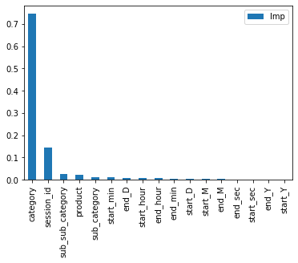

```python
### Plot importances features
Important.plot(kind='bar')
```

```python
## Get the predictions on train and test
train_pred = clf.predict(X_train)
validation_pred = clf.predict(X_test)
```

```python
## Get confusion matrix for train and validation data
confusion_matrix_train = confusion_matrix(y_train, train_pred)
confusion_matrix_validation = confusion_matrix(y_test, validation_pred)

print(confusion_matrix_train)
print(confusion_matrix_validation)
```

```
[[14336   371]
 [ 1369  2524]]
[[3602  101]
 [ 325  623]]
```

```python
Accuracy_Train=(confusion_matrix_train[0,0]+confusion_matrix_train[1,1])/(confusion_matrix_train[0,0]+confusion_matrix_train[0,1]+confusion_matrix_train[1,0]+confusion_matrix_train[1,1])
TNR_Train= confusion_matrix_train[0,0]/(confusion_matrix_train[0,0]+confusion_matrix_train[0,1])
TPR_Train= confusion_matrix_train[1,1]/(confusion_matrix_train[1,0]+confusion_matrix_train[1,1])

print("Train TNR: ",TNR_Train)
print("\n")
print("Train TPR: ",TPR_Train)
print("\n")
print("Train Accuracy: ",Accuracy_Train)
```

```
Train TNR:  0.9747739171822941


Train TPR:  0.6483431800667866


Train Accuracy:  0.9064516129032258
```

```python
Accuracy_Test=(confusion_matrix_validation[0,0]+confusion_matrix_validation[1,1])/(confusion_matrix_validation[0,0]+confusion_matrix_validation[0,1]+confusion_matrix_validation[1,0]+confusion_matrix_validation[1,1])
TNR_Test= confusion_matrix_validation[0,0]/(confusion_matrix_validation[0,0] +confusion_matrix_validation[0,1])
TPR_Test= confusion_matrix_validation[1,1]/(confusion_matrix_validation[1,0] +confusion_matrix_validation[1,1])

print("Validation TNR: ",TNR_Test)
print("\n")
print("Validation TPR: ",TPR_Test)
print("\n")
print("Validation Accuracy: ",Accuracy_Test)
```

```
Validation TNR:  0.9727248177153659


Validation TPR:  0.6571729957805907


Validation Accuracy:  0.9084067942377984
```

```python
## Display classification metrics for train data
print(classification_report(y_true=y_train,y_pred=train_pred))
```

```
              precision    recall  f1-score   support

           0       0.91      0.97      0.94     14707
           1       0.87      0.65      0.74      3893

    accuracy                           0.91     18600
   macro avg       0.89      0.81      0.84     18600
weighted avg       0.90      0.91      0.90     18600
```

```python
## Display classification metrics for validation data
print(classification_report(y_true=y_test,y_pred=validation_pred))
```

```
              precision    recall  f1-score   support

           0       0.92      0.97      0.94      3703
           1       0.86      0.66      0.75       948

    accuracy                           0.91      4651
   macro avg       0.89      0.81      0.84      4651
weighted avg       0.91      0.91      0.90      4651
```

```python
## Try with different parameters to find best mode
param_grid = {"criterion": ["gini", "entropy"],
              "min_samples_split": [2, 10, 20],
              "max_depth": [2, 5, 10],
              "min_samples_leaf": [1, 5, 10],
              "max_leaf_nodes": [5, 10, 20],
              }
```

```python
## Instantiate model and send to Grid search to find best model and fit a model
dt = DecisionTreeClassifier()
clf = GridSearchCV(dt, param_grid, cv=10)
%time clf.fit(X_train, y_train)
```

```
Wall time: 2min 12s
```

```
GridSearchCV(cv=10, error_score=nan,
             estimator=DecisionTreeClassifier(ccp_alpha=0.0, class_weight=None,
                                              criterion='gini', max_depth=None,
                                              max_features=None,
                                              max_leaf_nodes=None,
                                              min_impurity_decrease=0.0,
                                              min_impurity_split=None,
                                              min_samples_leaf=1,
                                              min_samples_split=2,
                                              min_weight_fraction_leaf=0.0,
                                              presort='deprecated',
                                              random_state=None,
                                              splitter='best'),
             iid='deprecated', n_jobs=None,
             param_grid={'criterion': ['gini', 'entropy'],
                         'max_depth': [2, 5, 10], 'max_leaf_nodes': [5, 10, 20],
                         'min_samples_leaf': [1, 5, 10],
                         'min_samples_split': [2, 10, 20]},
             pre_dispatch='2*n_jobs', refit=True, return_train_score=False,
             scoring=None, verbose=0)
```

```python
## Get best parameters from model
clf.best_params_
```

```
{'criterion': 'entropy',
 'max_depth': 10,
 'max_leaf_nodes': 20,
 'min_samples_leaf': 1,
 'min_samples_split': 2}
```

```python
## Instantiate Decision Tree with best parameters and fit a model
dt = DecisionTreeClassifier(criterion='entropy',max_depth=10,max_leaf_nodes=20)
%time dt.fit(X_train, y_train)
```

```
Wall time: 92.3 ms
```

```
DecisionTreeClassifier(ccp_alpha=0.0, class_weight=None, criterion='entropy',
                       max_depth=10, max_features=None, max_leaf_nodes=20,
                       min_impurity_decrease=0.0, min_impurity_split=None,
                       min_samples_leaf=1, min_samples_split=2,
                       min_weight_fraction_leaf=0.0, presort='deprecated',
                       random_state=None, splitter='best')
```

```python
## Get prediction on train and validation
train_pred = dt.predict(X_train)
validation_pred= dt.predict(X_test)
```

```python
## Get confusion matrix on train and validation
confusion_matrix_train = confusion_matrix(y_train, train_pred)
confusion_matrix_validation = confusion_matrix(y_test, validation_pred)

print(confusion_matrix_train)
print(confusion_matrix_validation)
```

```
[[14118   589]
 [ 1473  2420]]
[[3570  133]
 [ 341  607]]
```

```python
Accuracy_Train=(confusion_matrix_train[0,0]+confusion_matrix_train[1,1])/(confusion_matrix_train[0,0]+confusion_matrix_train[0,1]+confusion_matrix_train[1,0]+confusion_matrix_train[1,1])
TNR_Train= confusion_matrix_train[0,0]/(confusion_matrix_train[0,0]+confusion_matrix_train[0,1])
TPR_Train= confusion_matrix_train[1,1]/(confusion_matrix_train[1,0]+confusion_matrix_train[1,1])

print("Train TNR: ",TNR_Train)
print("\n")
print("Train TPR: ",TPR_Train)
print("\n")
print("Train Accuracy: ",Accuracy_Train)
```

```
Train TNR:  0.9599510437206772


Train TPR:  0.6216285640893913


Train Accuracy:  0.8891397849462366
```

```python
Accuracy_Test=(confusion_matrix_validation[0,0]+confusion_matrix_validation[1,1])/(confusion_matrix_validation[0,0]+confusion_matrix_validation[0,1]+confusion_matrix_validation[1,0]+confusion_matrix_validation[1,1])
TNR_Test= confusion_matrix_validation[0,0]/(confusion_matrix_validation[0,0] +confusion_matrix_validation[0,1])
TPR_Test= confusion_matrix_validation[1,1]/(confusion_matrix_validation[1,0] +confusion_matrix_validation[1,1])

print("Validation TNR: ",TNR_Test)
print("\n")
print("Validation TPR: ",TPR_Test)
print("\n")
print("Validation Accuracy: ",Accuracy_Test)
```

```
Validation TNR:  0.9640831758034026


Validation TPR:  0.640295358649789


Validation Accuracy:  0.8980864330251559
```

```python
## Display classification metrics for train data
print(classification_report(y_true=y_train,y_pred=train_pred))
```

```
              precision    recall  f1-score   support

           0       0.91      0.96      0.93     14707
           1       0.80      0.62      0.70      3893

    accuracy                           0.89     18600
   macro avg       0.85      0.79      0.82     18600
weighted avg       0.88      0.89      0.88     18600
```

```python
## Display classification metrics for validation data
print(classification_report(y_true=y_test,y_pred=validation_pred))
```

```
              precision    recall  f1-score   support

           0       0.91      0.96      0.94      3703
           1       0.82      0.64      0.72       948

    accuracy                           0.90      4651
   macro avg       0.87      0.80      0.83      4651
weighted avg       0.89      0.90      0.89      4651
```

```python
## Get copy of test data
test_data = test.copy()
```

```python
## Get the predictions on test data
y_pred = dt.predict(test_data)
```

```python
y_pred
```

```
array([0, 0, 0, ..., 1, 0, 0])
```

```python
## Do inverse transform on y_ped so that we will get it's original values(male,female)
test_data['gender'] = le_gender.inverse_transform(y_pred)
```

```python
## Do inverse transform on session_id so that we will get it's original values
test_data['session_id'] = le_session.inverse_transform(test_data['session_id'])
```

```python
## Check first 5 records after doing inverse transformation
test_data.head()
```

|  | session_id | start_Y | start_M | start_D | end_Y | end_M | end_D | start_hour | start_min | start_sec | end_hour | end_min | end_sec | category | sub_category | sub_sub_category | product | gender |
| --- | --- | --- | --- | --- | --- | --- | --- | --- | --- | --- | --- | --- | --- | --- | --- | --- | --- | --- |
| 0 | u12112 | 0 | 6 | 0 | 0 | 6 | 0 | 13 | 36 | 0 | 13 | 36 | 0 | 1 | 2 | 5 | 12675 | female |
| 1 | u19725 | 0 | 9 | 7 | 0 | 9 | 7 | 13 | 52 | 0 | 13 | 52 | 0 | 1 | 4 | 66 | 1407 | female |
| 2 | u11795 | 0 | 0 | 0 | 0 | 0 | 0 | 10 | 44 | 0 | 10 | 44 | 0 | 1 | 1 | 3 | 8129 | female |
| 3 | u22639 | 0 | 6 | 0 | 0 | 6 | 0 | 20 | 19 | 0 | 20 | 22 | 0 | 1 | 2 | 77 | 14345 | female |
| 3 | u22639 | 0 | 6 | 0 | 0 | 6 | 0 | 20 | 19 | 0 | 20 | 22 | 0 | 1 | 2 | 77 | 14346 | female |

```python
## Check the dimensions of the test_data before dropping dupliccate data
test_data.shape
```

```
(10204, 18)
```

```python
## Drop duplicate session_id values
test_data = test_data.drop_duplicates(subset=['session_id'])
```

```python
## Check the dimensions of the test_data after dropping dupliccate data
test_data.shape
```

```
(4500, 18)
```

```python
## Get session_id,gender from test_data and store into to_submit
to_submit = test_data[['session_id', 'gender']]
```

```python
## Check first 5 records of to_submit
to_submit.head()
```

|  | session_id | gender |
| --- | --- | --- |
| 0 | u12112 | female |
| 1 | u19725 | female |
| 2 | u11795 | female |
| 3 | u22639 | female |
| 4 | u18034 | female |

```python
## Get gender count value
to_submit.gender.value_counts()
```

```
female    3728
male       772
Name: gender, dtype: int64
```

```python
## store to_submit into csv file with name decisiontree_model
to_submit.to_csv('decisiontree_model.csv',index = False)
```

## 7.3 Naive Bayes

```python
## Instantiate Navie Bayes Model
model = GaussianNB()
```

```python
## Fit a model
model.fit(X_train,y_train)
```

```
GaussianNB(priors=None, var_smoothing=1e-09)
```

```python
## Get prediction on train and validation data
predict_train = model.predict(X_train)
predict_validation = model.predict(X_test)
```

```python
## Get confusion matrix for train data
confusion_matrix_train = confusion_matrix(y_train, predict_train)
print(confusion_matrix_train)
```

```
[[13754   953]
 [ 3174   719]]
```

```python
## Get confusion matrix for validation data
confusion_matrix_validation = confusion_matrix(y_test, predict_validation)
print(confusion_matrix_validation)
```

```
[[3479  224]
 [ 771  177]]
```

```python
Accuracy_Train=(confusion_matrix_train[0,0]+confusion_matrix_train[1,1])/(confusion_matrix_train[0,0]+confusion_matrix_train[0,1]+confusion_matrix_train[1,0]+confusion_matrix_train[1,1])
TNR_Train= confusion_matrix_train[0,0]/(confusion_matrix_train[0,0]+confusion_matrix_train[0,1])
TPR_Train= confusion_matrix_train[1,1]/(confusion_matrix_train[1,0]+confusion_matrix_train[1,1])

print("Train TNR: ",TNR_Train)
print("\n")
print("Train TPR: ",TPR_Train)
print("\n")
print("Train Accuracy: ",Accuracy_Train)
```

```
Train TNR:  0.9352009247297205


Train TPR:  0.18469047007449269


Train Accuracy:  0.7781182795698924
```

```python
Accuracy_Test=(confusion_matrix_validation[0,0]+confusion_matrix_validation[1,1])/(confusion_matrix_validation[0,0]+confusion_matrix_validation[0,1]+confusion_matrix_validation[1,0]+confusion_matrix_validation[1,1])
TNR_Test= confusion_matrix_validation[0,0]/(confusion_matrix_validation[0,0] +confusion_matrix_validation[0,1])
TPR_Test= confusion_matrix_validation[1,1]/(confusion_matrix_validation[1,0] +confusion_matrix_validation[1,1])

print("Validation TNR: ",TNR_Test)
print("\n")
print("Validation TPR: ",TPR_Test)
print("\n")
print("Validation Accuracy: ",Accuracy_Test)
```

```
Validation TNR:  0.9395085066162571


Validation TPR:  0.18670886075949367


Validation Accuracy:  0.7860675123629327
```

```python
## Display classification metrics for train data
print(classification_report(y_true=y_train,y_pred=train_pred))
```

```
              precision    recall  f1-score   support

           0       0.91      0.96      0.93     14707
           1       0.80      0.62      0.70      3893

    accuracy                           0.89     18600
   macro avg       0.85      0.79      0.82     18600
weighted avg       0.88      0.89      0.88     18600
```

```python
## Display classification metrics for validation data
print(classification_report(y_true=y_test,y_pred=validation_pred))
```

```
              precision    recall  f1-score   support

           0       0.91      0.96      0.94      3703
           1       0.82      0.64      0.72       948

    accuracy                           0.90      4651
   macro avg       0.87      0.80      0.83      4651
weighted avg       0.89      0.90      0.89      4651
```

```python
## Get copy of test data
test_data = test.copy()
```

```python
## Get the predictions on test data
y_pred = model.predict(test_data)
```

```python
y_pred
```

```
array([0, 0, 0, ..., 0, 0, 0])
```

```python
## Do inverse transform on y_ped so that we will get it's original values(male,female)
test_data['gender'] = le_gender.inverse_transform(y_pred)
```

```python
## Do inverse transform on session_id so that we will get it's original values
test_data['session_id'] = le_session.inverse_transform(test_data['session_id'])
```

```python
## Check first 5 records after doing inverse transformation
test_data.head()
```

|  | session_id | start_Y | start_M | start_D | end_Y | end_M | end_D | start_hour | start_min | start_sec | end_hour | end_min | end_sec | category | sub_category | sub_sub_category | product | gender |
| --- | --- | --- | --- | --- | --- | --- | --- | --- | --- | --- | --- | --- | --- | --- | --- | --- | --- | --- |
| 0 | u12112 | 0 | 6 | 0 | 0 | 6 | 0 | 13 | 36 | 0 | 13 | 36 | 0 | 1 | 2 | 5 | 12675 | female |
| 1 | u19725 | 0 | 9 | 7 | 0 | 9 | 7 | 13 | 52 | 0 | 13 | 52 | 0 | 1 | 4 | 66 | 1407 | female |
| 2 | u11795 | 0 | 0 | 0 | 0 | 0 | 0 | 10 | 44 | 0 | 10 | 44 | 0 | 1 | 1 | 3 | 8129 | female |
| 3 | u22639 | 0 | 6 | 0 | 0 | 6 | 0 | 20 | 19 | 0 | 20 | 22 | 0 | 1 | 2 | 77 | 14345 | female |
| 3 | u22639 | 0 | 6 | 0 | 0 | 6 | 0 | 20 | 19 | 0 | 20 | 22 | 0 | 1 | 2 | 77 | 14346 | female |

```python
## Check the dimensions of the test_data before dropping dupliccate data
test_data.shape
```

```
(10204, 18)
```

```python
## Drop duplicate session_id values
test_data = test_data.drop_duplicates(subset=['session_id'])
```

```python
## Check the dimensions of the test_data after dropping dupliccate data
test_data.shape
```

```
(4500, 18)
```

```python
## Get session_id,gender from test_data and store into to_submit
to_submit = test_data[['session_id', 'gender']]
```

```python
## Check first 5 records of to_submit
to_submit.head()
```

|  | session_id | gender |
| --- | --- | --- |
| 0 | u12112 | female |
| 1 | u19725 | female |
| 2 | u11795 | female |
| 3 | u22639 | female |
| 4 | u18034 | female |

```python
## Get gender count value
to_submit.gender.value_counts()
```

```
female    4071
male       429
Name: gender, dtype: int64
```

```python
## store to_submit into csv file with name naivebayes_model
to_submit.to_csv('naivebayes_model.csv',index = False)
```

## 7.4 KNN

```python
## Instantiate KNN model
knn = KNeighborsClassifier(algorithm = 'brute', n_neighbors = 3,
                           metric = "euclidean")
```

```python
## Fit a model
knn.fit(X_train, y_train)
```

```
KNeighborsClassifier(algorithm='brute', leaf_size=30, metric='euclidean',
                     metric_params=None, n_jobs=None, n_neighbors=3, p=2,
                     weights='uniform')
```

```python
## Get prediction on trian and validation data
train_pred = knn.predict(X_train)
validation_pred = knn.predict(X_test)
```

```python
## Get confusion matrix for train data
confusion_matrix_train = confusion_matrix(y_train, train_pred)
print(confusion_matrix_train)
```

```
[[14225   482]
 [  953  2940]]
```

```python
## Get confusion matrix for validation data
confusion_matrix_validation = confusion_matrix(y_test, validation_pred)
print(confusion_matrix_validation)
```

```
[[3430  273]
 [ 368  580]]
```

```python
Accuracy_Train=(confusion_matrix_train[0,0]+confusion_matrix_train[1,1])/(confusion_matrix_train[0,0]+confusion_matrix_train[0,1]+confusion_matrix_train[1,0]+confusion_matrix_train[1,1])
TNR_Train= confusion_matrix_train[0,0]/(confusion_matrix_train[0,0]+confusion_matrix_train[0,1])
TPR_Train= confusion_matrix_train[1,1]/(confusion_matrix_train[1,0]+confusion_matrix_train[1,1])

print("Train TNR: ",TNR_Train)
print("\n")
print("Train TPR: ",TPR_Train)
print("\n")
print("Train Accuracy: ",Accuracy_Train)
```

```
Train TNR:  0.9672264907867002


Train TPR:  0.7552016439763678


Train Accuracy:  0.9228494623655914
```

```python
Accuracy_Test=(confusion_matrix_validation[0,0]+confusion_matrix_validation[1,1])/(confusion_matrix_validation[0,0]+confusion_matrix_validation[0,1]+confusion_matrix_validation[1,0]+confusion_matrix_validation[1,1])
TNR_Test= confusion_matrix_validation[0,0]/(confusion_matrix_validation[0,0] +confusion_matrix_validation[0,1])
TPR_Test= confusion_matrix_validation[1,1]/(confusion_matrix_validation[1,0] +confusion_matrix_validation[1,1])

print("Validation TNR: ",TNR_Test)
print("\n")
print("Validation TPR: ",TPR_Test)
print("\n")
print("Validation Accuracy: ",Accuracy_Test)
```

```
Validation TNR:  0.9262759924385633


Validation TPR:  0.6118143459915611


Validation Accuracy:  0.8621801763061707
```

```python
## Display classification metrics for train data
print(classification_report(y_true=y_train,y_pred=train_pred))
```

```
              precision    recall  f1-score   support

           0       0.94      0.97      0.95     14707
           1       0.86      0.76      0.80      3893

    accuracy                           0.92     18600
   macro avg       0.90      0.86      0.88     18600
weighted avg       0.92      0.92      0.92     18600
```

```python
## Display classification metrics for validation data
print(classification_report(y_true=y_test,y_pred=validation_pred))
```

```
              precision    recall  f1-score   support

           0       0.90      0.93      0.91      3703
           1       0.68      0.61      0.64       948

    accuracy                           0.86      4651
   macro avg       0.79      0.77      0.78      4651
weighted avg       0.86      0.86      0.86      4651
```

```python
## Get copy of test data
test_data = test.copy()
```

```python
## Get the predictions on test data
y_pred = knn.predict(test_data)
```

```python
y_pred
```

```
array([0, 0, 0, ..., 0, 0, 0])
```

```python
## Do inverse transform on y_ped so that we will get it's original values(male,female)
test_data['gender'] = le_gender.inverse_transform(y_pred)
```

```python
## Do inverse transform on session_id so that we will get it's original values
test_data['session_id'] = le_session.inverse_transform(test_data['session_id'])
```

```python
## Check first 5 records after doing inverse transformation
test_data.head()
```

|  | session_id | start_Y | start_M | start_D | end_Y | end_M | end_D | start_hour | start_min | start_sec | end_hour | end_min | end_sec | category | sub_category | sub_sub_category | product | gender |
| --- | --- | --- | --- | --- | --- | --- | --- | --- | --- | --- | --- | --- | --- | --- | --- | --- | --- | --- |
| 0 | u12112 | 0 | 6 | 0 | 0 | 6 | 0 | 13 | 36 | 0 | 13 | 36 | 0 | 1 | 2 | 5 | 12675 | female |
| 1 | u19725 | 0 | 9 | 7 | 0 | 9 | 7 | 13 | 52 | 0 | 13 | 52 | 0 | 1 | 4 | 66 | 1407 | female |
| 2 | u11795 | 0 | 0 | 0 | 0 | 0 | 0 | 10 | 44 | 0 | 10 | 44 | 0 | 1 | 1 | 3 | 8129 | female |
| 3 | u22639 | 0 | 6 | 0 | 0 | 6 | 0 | 20 | 19 | 0 | 20 | 22 | 0 | 1 | 2 | 77 | 14345 | male |
| 3 | u22639 | 0 | 6 | 0 | 0 | 6 | 0 | 20 | 19 | 0 | 20 | 22 | 0 | 1 | 2 | 77 | 14346 | male |

```python
## Check the dimensions of the test_data before dropping dupliccate data
test_data.shape
```

```
(10204, 18)
```

```python
## Drop duplicate session_id values
test_data = test_data.drop_duplicates(subset=['session_id'])
```

```python
## Check the dimensions of the test_data after dropping dupliccate data
test_data.shape
```

```
(4500, 18)
```

```python
## Get session_id,gender from test_data and store into to_submit
to_submit = test_data[['session_id', 'gender']]
```

```python
## Check first 5 records of to_submit
to_submit.head()
```

|  | session_id | gender |
| --- | --- | --- |
| 0 | u12112 | female |
| 1 | u19725 | female |
| 2 | u11795 | female |
| 3 | u22639 | male |
| 4 | u18034 | female |

```python
## Get gender count value
to_submit.gender.value_counts()
```

```
female    3664
male       836
Name: gender, dtype: int64
```

```python
## store to_submit into csv file with name knn_model
to_submit.to_csv('knn_model.csv',index = False)
```

## 7.5 Random Forest

```python
## Instantiate RandoForest model
rc = RandomForestClassifier(n_estimators=30,max_depth=10,n_jobs=-1)
```

```python
## Fit a model
rc.fit(X_train,y_train)
```

```
RandomForestClassifier(bootstrap=True, ccp_alpha=0.0, class_weight=None,
                       criterion='gini', max_depth=10, max_features='auto',
                       max_leaf_nodes=None, max_samples=None,
                       min_impurity_decrease=0.0, min_impurity_split=None,
                       min_samples_leaf=1, min_samples_split=2,
                       min_weight_fraction_leaf=0.0, n_estimators=30, n_jobs=-1,
                       oob_score=False, random_state=None, verbose=0,
                       warm_start=False)
```

```python
## Get predictions on train and validation data
train_pred = rc.predict(X_train)
validation_pred = rc.predict(X_test)
```

```python
## Get confusion matrix for train data
confusion_matrix_train = confusion_matrix(y_train, train_pred)
print(confusion_matrix_train)
```

```
[[14393   314]
 [ 1399  2494]]
```

```python
## Get confusion matrix for validation data
confusion_matrix_validation = confusion_matrix(y_test, validation_pred)
print(confusion_matrix_validation)
```

```
[[3620   83]
 [ 337  611]]
```

```python
Accuracy_Train=(confusion_matrix_train[0,0]+confusion_matrix_train[1,1])/(confusion_matrix_train[0,0]+confusion_matrix_train[0,1]+confusion_matrix_train[1,0]+confusion_matrix_train[1,1])
TNR_Train= confusion_matrix_train[0,0]/(confusion_matrix_train[0,0]+confusion_matrix_train[0,1])
TPR_Train= confusion_matrix_train[1,1]/(confusion_matrix_train[1,0]+confusion_matrix_train[1,1])

print("Train TNR: ",TNR_Train)
print("\n")
print("Train TPR: ",TPR_Train)
print("\n")
print("Train Accuracy: ",Accuracy_Train)
```

```
Train TNR:  0.9786496226286803


Train TPR:  0.6406370408425379


Train Accuracy:  0.9079032258064517
```

```python
Accuracy_Test=(confusion_matrix_validation[0,0]+confusion_matrix_validation[1,1])/(confusion_matrix_validation[0,0]+confusion_matrix_validation[0,1]+confusion_matrix_validation[1,0]+confusion_matrix_validation[1,1])
TNR_Test= confusion_matrix_validation[0,0]/(confusion_matrix_validation[0,0] +confusion_matrix_validation[0,1])
TPR_Test= confusion_matrix_validation[1,1]/(confusion_matrix_validation[1,0] +confusion_matrix_validation[1,1])

print("Validation TNR: ",TNR_Test)
print("\n")
print("Validation TPR: ",TPR_Test)
print("\n")
print("Validation Accuracy: ",Accuracy_Test)
```

```
Validation TNR:  0.9775857412908453


Validation TPR:  0.6445147679324894


Validation Accuracy:  0.9096968393893786
```

```python
## Display classification metrics for train data
print(classification_report(y_true=y_train,y_pred=train_pred))
```

```
              precision    recall  f1-score   support

           0       0.91      0.98      0.94     14707
           1       0.89      0.64      0.74      3893

    accuracy                           0.91     18600
   macro avg       0.90      0.81      0.84     18600
weighted avg       0.91      0.91      0.90     18600
```

```python
## Display classification metrics for validation data
print(classification_report(y_true=y_test,y_pred=validation_pred))
```

```
              precision    recall  f1-score   support

           0       0.91      0.98      0.95      3703
           1       0.88      0.64      0.74       948

    accuracy                           0.91      4651
   macro avg       0.90      0.81      0.84      4651
weighted avg       0.91      0.91      0.90      4651
```

```python
## Get copy of test data
test_data = test.copy()
```

```python
## Get the predictions on test data
y_pred = rc.predict(test_data)
```

```python
y_pred
```

```
array([0, 0, 0, ..., 1, 0, 0])
```

```python
## Do inverse transform on y_ped so that we will get it's original values(male,female)
test_data['gender'] = le_gender.inverse_transform(y_pred)
```

```python
## Do inverse transform on session_id so that we will get it's original values
test_data['session_id'] = le_session.inverse_transform(test_data['session_id'])
```

```python
## Check first 5 records after doing inverse transformation
test_data.head()
```

|  | session_id | start_Y | start_M | start_D | end_Y | end_M | end_D | start_hour | start_min | start_sec | end_hour | end_min | end_sec | category | sub_category | sub_sub_category | product | gender |
| --- | --- | --- | --- | --- | --- | --- | --- | --- | --- | --- | --- | --- | --- | --- | --- | --- | --- | --- |
| 0 | u12112 | 0 | 6 | 0 | 0 | 6 | 0 | 13 | 36 | 0 | 13 | 36 | 0 | 1 | 2 | 5 | 12675 | female |
| 1 | u19725 | 0 | 9 | 7 | 0 | 9 | 7 | 13 | 52 | 0 | 13 | 52 | 0 | 1 | 4 | 66 | 1407 | female |
| 2 | u11795 | 0 | 0 | 0 | 0 | 0 | 0 | 10 | 44 | 0 | 10 | 44 | 0 | 1 | 1 | 3 | 8129 | female |
| 3 | u22639 | 0 | 6 | 0 | 0 | 6 | 0 | 20 | 19 | 0 | 20 | 22 | 0 | 1 | 2 | 77 | 14345 | female |
| 3 | u22639 | 0 | 6 | 0 | 0 | 6 | 0 | 20 | 19 | 0 | 20 | 22 | 0 | 1 | 2 | 77 | 14346 | female |

```python
## Check the dimensions of the test_data before dropping dupliccate data
test_data.shape
```

```
(10204, 18)
```

```python
## Drop duplicate session_id values
test_data = test_data.drop_duplicates(subset=['session_id'])
```

```python
## Check the dimensions of the test_data after dropping dupliccate data
test_data.shape
```

```
(4500, 18)
```

```python
## Get session_id,gender from test_data and store into to_submit
to_submit = test_data[['session_id', 'gender']]
```

```python
## Check first 5 records of to_submit
to_submit.head()
```

|  | session_id | gender |
| --- | --- | --- |
| 0 | u12112 | female |
| 1 | u19725 | female |
| 2 | u11795 | female |
| 3 | u22639 | female |
| 4 | u18034 | female |

```python
## Get gender count value
to_submit.gender.value_counts()
```

```
female    3788
male       712
Name: gender, dtype: int64
```

```python
## store to_submit into csv file with name randomforest_model
to_submit.to_csv('randomforest_model.csv',index = False)
```

## 7.6 Bagging

```python
## Instantiate Bagging model and fit it
clf = BaggingClassifier(n_estimators=10)
clf.fit(X=X_train, y=y_train)
```

```
BaggingClassifier(base_estimator=None, bootstrap=True, bootstrap_features=False,
                  max_features=1.0, max_samples=1.0, n_estimators=10,
                  n_jobs=None, oob_score=False, random_state=None, verbose=0,
                  warm_start=False)
```

```python
## Get prediction on train and validation data
train_pred = clf.predict(X_train)
validation_pred = clf.predict(X_test)
```

```python
## Get confusion matrix for train data
confusion_matrix_train = confusion_matrix(y_train, train_pred)
print(confusion_matrix_train)
```

```
[[14703     4]
 [   64  3829]]
```

```python
## Get confusion matrix for validation data
confusion_matrix_validation = confusion_matrix(y_test, validation_pred)
print(confusion_matrix_validation)
```

```
[[3652   51]
 [ 154  794]]
```

```python
Accuracy_Train=(confusion_matrix_train[0,0]+confusion_matrix_train[1,1])/(confusion_matrix_train[0,0]+confusion_matrix_train[0,1]+confusion_matrix_train[1,0]+confusion_matrix_train[1,1])
TNR_Train= confusion_matrix_train[0,0]/(confusion_matrix_train[0,0]+confusion_matrix_train[0,1])
TPR_Train= confusion_matrix_train[1,1]/(confusion_matrix_train[1,0]+confusion_matrix_train[1,1])

print("Train TNR: ",TNR_Train)
print("\n")
print("Train TPR: ",TPR_Train)
print("\n")
print("Train Accuracy: ",Accuracy_Train)
```

```
Train TNR:  0.9997280206704291


Train TPR:  0.9835602363216028


Train Accuracy:  0.9963440860215054
```

```python
Accuracy_Test=(confusion_matrix_validation[0,0]+confusion_matrix_validation[1,1])/(confusion_matrix_validation[0,0]+confusion_matrix_validation[0,1]+confusion_matrix_validation[1,0]+confusion_matrix_validation[1,1])
TNR_Test= confusion_matrix_validation[0,0]/(confusion_matrix_validation[0,0] +confusion_matrix_validation[0,1])
TPR_Test= confusion_matrix_validation[1,1]/(confusion_matrix_validation[1,0] +confusion_matrix_validation[1,1])

print("Validation TNR: ",TNR_Test)
print("\n")
print("Validation TPR: ",TPR_Test)
print("\n")
print("Validation Accuracy: ",Accuracy_Test)
```

```
Validation TNR:  0.9862273832028086


Validation TPR:  0.8375527426160337


Validation Accuracy:  0.9559234573210063
```

```python
## Display classification metrics for train data
print(classification_report(y_true=y_train,y_pred=train_pred))
```

```
              precision    recall  f1-score   support

           0       1.00      1.00      1.00     14707
           1       1.00      0.98      0.99      3893

    accuracy                           1.00     18600
   macro avg       1.00      0.99      0.99     18600
weighted avg       1.00      1.00      1.00     18600
```

```python
## Display classification metrics for validation data
print(classification_report(y_true=y_test,y_pred=validation_pred))
```

```
              precision    recall  f1-score   support

           0       0.96      0.99      0.97      3703
           1       0.94      0.84      0.89       948

    accuracy                           0.96      4651
   macro avg       0.95      0.91      0.93      4651
weighted avg       0.96      0.96      0.95      4651
```

```python
## Get copy of test data
test_data = test.copy()
```

```python
## Get the predictions on test data
y_pred = clf.predict(test_data)
```

```python
y_pred
```

```
array([0, 0, 0, ..., 0, 0, 0])
```

```python
## Do inverse transform on y_ped so that we will get it's original values(male,female)
test_data['gender'] = le_gender.inverse_transform(y_pred)
```

```python
## Do inverse transform on session_id so that we will get it's original values
test_data['session_id'] = le_session.inverse_transform(test_data['session_id'])
```

```python
## Check first 5 records after doing inverse transformation
test_data.head()
```

|  | session_id | start_Y | start_M | start_D | end_Y | end_M | end_D | start_hour | start_min | start_sec | end_hour | end_min | end_sec | category | sub_category | sub_sub_category | product | gender |
| --- | --- | --- | --- | --- | --- | --- | --- | --- | --- | --- | --- | --- | --- | --- | --- | --- | --- | --- |
| 0 | u12112 | 0 | 6 | 0 | 0 | 6 | 0 | 13 | 36 | 0 | 13 | 36 | 0 | 1 | 2 | 5 | 12675 | female |
| 1 | u19725 | 0 | 9 | 7 | 0 | 9 | 7 | 13 | 52 | 0 | 13 | 52 | 0 | 1 | 4 | 66 | 1407 | female |
| 2 | u11795 | 0 | 0 | 0 | 0 | 0 | 0 | 10 | 44 | 0 | 10 | 44 | 0 | 1 | 1 | 3 | 8129 | female |
| 3 | u22639 | 0 | 6 | 0 | 0 | 6 | 0 | 20 | 19 | 0 | 20 | 22 | 0 | 1 | 2 | 77 | 14345 | male |
| 3 | u22639 | 0 | 6 | 0 | 0 | 6 | 0 | 20 | 19 | 0 | 20 | 22 | 0 | 1 | 2 | 77 | 14346 | male |

```python
## Check the dimensions of the test_data before dropping dupliccate data
test_data.shape
```

```
(10204, 18)
```

```python
## Drop duplicate session_id values
test_data = test_data.drop_duplicates(subset=['session_id'])
```

```python
## Check the dimensions of the test_data after dropping dupliccate data
test_data.shape
```

```
(4500, 18)
```

```python
## Get session_id,gender from test_data and store into to_submit
to_submit = test_data[['session_id', 'gender']]
```

```python
## Check first 5 records of to_submit
to_submit.head()
```

|  | session_id | gender |
| --- | --- | --- |
| 0 | u12112 | female |
| 1 | u19725 | female |
| 2 | u11795 | female |
| 3 | u22639 | male |
| 4 | u18034 | male |

```python
## Get gender count value
to_submit.gender.value_counts()
```

```
female    3710
male       790
Name: gender, dtype: int64
```

```python
## store to_submit into csv file with name bagging_model
to_submit.to_csv('bagging_model.csv',index = False)
```

## 7.7 AdaBoost

```python
## Instantiate AdaBoost model and fit it
Adaboost_model = AdaBoostClassifier(n_estimators=50,learning_rate=1)
%time Adaboost_model.fit(X_train, y_train)
```

```
Wall time: 732 ms
```

```
AdaBoostClassifier(algorithm='SAMME.R', base_estimator=None, learning_rate=1,
                   n_estimators=50, random_state=None)
```

```python
## Get predictions on train and validation data
train_pred = Adaboost_model.predict(X_train)
validation_pred = Adaboost_model.predict(X_test)
```

```python
## Get confusion matrix for train data
confusion_matrix_train = confusion_matrix(y_train, train_pred)
print(confusion_matrix_train)
```

```
[[14171   536]
 [ 1585  2308]]
```

```python
## Get confusion matrrix for validation data
confusion_matrix_validation = confusion_matrix(y_test, validation_pred)
print(confusion_matrix_validation)
```

```
[[3575  128]
 [ 370  578]]
```

```python
Accuracy_Train=(confusion_matrix_train[0,0]+confusion_matrix_train[1,1])/(confusion_matrix_train[0,0]+confusion_matrix_train[0,1]+confusion_matrix_train[1,0]+confusion_matrix_train[1,1])
TNR_Train= confusion_matrix_train[0,0]/(confusion_matrix_train[0,0]+confusion_matrix_train[0,1])
TPR_Train= confusion_matrix_train[1,1]/(confusion_matrix_train[1,0]+confusion_matrix_train[1,1])

print("Train TNR: ",TNR_Train)
print("\n")
print("Train TPR: ",TPR_Train)
print("\n")
print("Train Accuracy: ",Accuracy_Train)
```

```
Train TNR:  0.9635547698374923


Train TPR:  0.5928589776521962


Train Accuracy:  0.8859677419354839
```

```python
Accuracy_Test=(confusion_matrix_validation[0,0]+confusion_matrix_validation[1,1])/(confusion_matrix_validation[0,0]+confusion_matrix_validation[0,1]+confusion_matrix_validation[1,0]+confusion_matrix_validation[1,1])
TNR_Test= confusion_matrix_validation[0,0]/(confusion_matrix_validation[0,0] +confusion_matrix_validation[0,1])
TPR_Test= confusion_matrix_validation[1,1]/(confusion_matrix_validation[1,0] +confusion_matrix_validation[1,1])

print("Validation TNR: ",TNR_Test)
print("\n")
print("Validation TPR: ",TPR_Test)
print("\n")
print("Validation Accuracy: ",Accuracy_Test)
```

```
Validation TNR:  0.965433432352147


Validation TPR:  0.609704641350211


Validation Accuracy:  0.8929262524188346
```

```python
## Display classification metrics for train data
print(classification_report(y_true=y_train,y_pred=train_pred))
```

```
              precision    recall  f1-score   support

           0       0.90      0.96      0.93     14707
           1       0.81      0.59      0.69      3893

    accuracy                           0.89     18600
   macro avg       0.86      0.78      0.81     18600
weighted avg       0.88      0.89      0.88     18600
```

```python
## Display classification metrics for validation data
print(classification_report(y_true=y_test,y_pred=validation_pred))
```

```
              precision    recall  f1-score   support

           0       0.91      0.97      0.93      3703
           1       0.82      0.61      0.70       948

    accuracy                           0.89      4651
   macro avg       0.86      0.79      0.82      4651
weighted avg       0.89      0.89      0.89      4651
```

```python
## Get copy of test data
test_data = test.copy()
```

```python
## Get the predictions on test data
y_pred = Adaboost_model.predict(test_data)
```

```python
y_pred
```

```
array([0, 0, 0, ..., 1, 0, 0])
```

```python
## Do inverse transform on y_ped so that we will get it's original values(male,female)
test_data['gender'] = le_gender.inverse_transform(y_pred)
```

```python
## Do inverse transform on session_id so that we will get it's original values
test_data['session_id'] = le_session.inverse_transform(test_data['session_id'])
```

```python
## Check first 5 records after doing inverse transformation
test_data.head()
```

|  | session_id | start_Y | start_M | start_D | end_Y | end_M | end_D | start_hour | start_min | start_sec | end_hour | end_min | end_sec | category | sub_category | sub_sub_category | product | gender |
| --- | --- | --- | --- | --- | --- | --- | --- | --- | --- | --- | --- | --- | --- | --- | --- | --- | --- | --- |
| 0 | u12112 | 0 | 6 | 0 | 0 | 6 | 0 | 13 | 36 | 0 | 13 | 36 | 0 | 1 | 2 | 5 | 12675 | female |
| 1 | u19725 | 0 | 9 | 7 | 0 | 9 | 7 | 13 | 52 | 0 | 13 | 52 | 0 | 1 | 4 | 66 | 1407 | female |
| 2 | u11795 | 0 | 0 | 0 | 0 | 0 | 0 | 10 | 44 | 0 | 10 | 44 | 0 | 1 | 1 | 3 | 8129 | female |
| 3 | u22639 | 0 | 6 | 0 | 0 | 6 | 0 | 20 | 19 | 0 | 20 | 22 | 0 | 1 | 2 | 77 | 14345 | female |
| 3 | u22639 | 0 | 6 | 0 | 0 | 6 | 0 | 20 | 19 | 0 | 20 | 22 | 0 | 1 | 2 | 77 | 14346 | female |

```python
## Check the dimensions of the test_data before dropping dupliccate data
test_data.shape
```

```
(10204, 18)
```

```python
## Drop duplicate session_id values
test_data = test_data.drop_duplicates(subset=['session_id'])
```

```python
## Check the dimensions of the test_data after dropping dupliccate data
test_data.shape
```

```
(4500, 18)
```

```python
## Get session_id,gender from test_data and store into to_submit
to_submit = test_data[['session_id', 'gender']]
```

```python
## Check first 5 records of to_submit
to_submit.head()
```

|  | session_id | gender |
| --- | --- | --- |
| 0 | u12112 | female |
| 1 | u19725 | female |
| 2 | u11795 | female |
| 3 | u22639 | female |
| 4 | u18034 | female |

```python
## Get gender count value
to_submit.gender.value_counts()
```

```
female    3778
male       722
Name: gender, dtype: int64
```

```python
## store to_submit into csv file with name adaboost_model
to_submit.to_csv('adaboost_model.csv',index = False)
```

## 7.8 Gradient Boosting

```python
## Instantiate GradientBoost model and fit it
gbm = GradientBoostingClassifier(n_estimators=100,learning_rate=0.3)
%time gbm.fit(X=X_train, y=y_train)
```

```
Wall time: 2.78 s
```

```
GradientBoostingClassifier(ccp_alpha=0.0, criterion='friedman_mse', init=None,
                           learning_rate=0.3, loss='deviance', max_depth=3,
                           max_features=None, max_leaf_nodes=None,
                           min_impurity_decrease=0.0, min_impurity_split=None,
                           min_samples_leaf=1, min_samples_split=2,
                           min_weight_fraction_leaf=0.0, n_estimators=100,
                           n_iter_no_change=None, presort='deprecated',
                           random_state=None, subsample=1.0, tol=0.0001,
                           validation_fraction=0.1, verbose=0,
                           warm_start=False)
```

```python
## Get predictions on train and validation data
train_pred = gbm.predict(X_train)
validation_pred = gbm.predict(X_test)
```

```python
## Get confusion matrix for train data
confusion_matrix_train = confusion_matrix(y_train, train_pred)
print(confusion_matrix_train)
```

```
[[14368   339]
 [  917  2976]]
```

```python
## Get confusion matrix for validation data
confusion_matrix_validation = confusion_matrix(y_test, validation_pred)
print(confusion_matrix_validation)
```

```
[[3620   83]
 [ 233  715]]
```

```python
Accuracy_Train=(confusion_matrix_train[0,0]+confusion_matrix_train[1,1])/(confusion_matrix_train[0,0]+confusion_matrix_train[0,1]+confusion_matrix_train[1,0]+confusion_matrix_train[1,1])
TNR_Train= confusion_matrix_train[0,0]/(confusion_matrix_train[0,0]+confusion_matrix_train[0,1])
TPR_Train= confusion_matrix_train[1,1]/(confusion_matrix_train[1,0]+confusion_matrix_train[1,1])

print("Train TNR: ",TNR_Train)
print("\n")
print("Train TPR: ",TPR_Train)
print("\n")
print("Train Accuracy: ",Accuracy_Train)
```

```
Train TNR:  0.9769497518188618


Train TPR:  0.7644490110454663


Train Accuracy:  0.9324731182795699
```

```python
Accuracy_Test=(confusion_matrix_validation[0,0]+confusion_matrix_validation[1,1])/(confusion_matrix_validation[0,0]+confusion_matrix_validation[0,1]+confusion_matrix_validation[1,0]+confusion_matrix_validation[1,1])
TNR_Test= confusion_matrix_validation[0,0]/(confusion_matrix_validation[0,0] +confusion_matrix_validation[0,1])
TPR_Test= confusion_matrix_validation[1,1]/(confusion_matrix_validation[1,0] +confusion_matrix_validation[1,1])

print("Validation TNR: ",TNR_Test)
print("\n")
print("Validation TPR: ",TPR_Test)
print("\n")
print("Validation Accuracy: ",Accuracy_Test)
```

```
Validation TNR:  0.9775857412908453


Validation TPR:  0.7542194092827004


Validation Accuracy:  0.9320576220167706
```

```python
## Display classification metrics for train data
print(classification_report(y_true=y_train,y_pred=train_pred))
```

```
              precision    recall  f1-score   support

           0       0.94      0.98      0.96     14707
           1       0.90      0.76      0.83      3893

    accuracy                           0.93     18600
   macro avg       0.92      0.87      0.89     18600
weighted avg       0.93      0.93      0.93     18600
```

```python
## Display classification metrics for validation data
print(classification_report(y_true=y_test,y_pred=validation_pred))
```

```
              precision    recall  f1-score   support

           0       0.94      0.98      0.96      3703
           1       0.90      0.75      0.82       948

    accuracy                           0.93      4651
   macro avg       0.92      0.87      0.89      4651
weighted avg       0.93      0.93      0.93      4651
```

```python
## Get copy of test data
test_data = test.copy()
```

```python
## Get the predictions on test data
y_pred = gbm.predict(test_data)
```

```python
y_pred
```

```
array([0, 0, 0, ..., 1, 0, 0])
```

```python
## Do inverse transform on y_ped so that we will get it's original values(male,female)
test_data['gender'] = le_gender.inverse_transform(y_pred)
```

```python
## Do inverse transform on session_id so that we will get it's original values
test_data['session_id'] = le_session.inverse_transform(test_data['session_id'])
```

```python
## Check first 5 records after doing inverse transformation
test_data.head()
```

|  | session_id | start_Y | start_M | start_D | end_Y | end_M | end_D | start_hour | start_min | start_sec | end_hour | end_min | end_sec | category | sub_category | sub_sub_category | product | gender |
| --- | --- | --- | --- | --- | --- | --- | --- | --- | --- | --- | --- | --- | --- | --- | --- | --- | --- | --- |
| 0 | u12112 | 0 | 6 | 0 | 0 | 6 | 0 | 13 | 36 | 0 | 13 | 36 | 0 | 1 | 2 | 5 | 12675 | female |
| 1 | u19725 | 0 | 9 | 7 | 0 | 9 | 7 | 13 | 52 | 0 | 13 | 52 | 0 | 1 | 4 | 66 | 1407 | female |
| 2 | u11795 | 0 | 0 | 0 | 0 | 0 | 0 | 10 | 44 | 0 | 10 | 44 | 0 | 1 | 1 | 3 | 8129 | female |
| 3 | u22639 | 0 | 6 | 0 | 0 | 6 | 0 | 20 | 19 | 0 | 20 | 22 | 0 | 1 | 2 | 77 | 14345 | male |
| 3 | u22639 | 0 | 6 | 0 | 0 | 6 | 0 | 20 | 19 | 0 | 20 | 22 | 0 | 1 | 2 | 77 | 14346 | male |

```python
## Check the dimensions of the test_data before dropping dupliccate data
test_data.shape
```

```
(10204, 18)
```

```python
## Drop duplicate session_id values
test_data = test_data.drop_duplicates(subset=['session_id'])
```

```python
## Check the dimensions of the test_data after dropping dupliccate data
test_data.shape
```

```
(4500, 18)
```

```python
## Get session_id,gender from test_data and store into to_submit
to_submit = test_data[['session_id', 'gender']]
```

```python
## Check first 5 records of to_submit
to_submit.head()
```

|  | session_id | gender |
| --- | --- | --- |
| 0 | u12112 | female |
| 1 | u19725 | female |
| 2 | u11795 | female |
| 3 | u22639 | male |
| 4 | u18034 | female |

```python
## Get gender count value
to_submit.gender.value_counts()
```

```
female    3691
male       809
Name: gender, dtype: int64
```

```python
## store to_submit into csv file with name gb_model
to_submit.to_csv('gb_model.csv',index = False)
```

## 7.9 SVC

```python
## Instantiate SVC model
svc_c10_rbf = SVC(C=10,kernel='rbf')
```

```python
## Fit a model
%time svc_c10_rbf.fit(X=X_train,y=y_train)
```

```
Wall time: 19.9 s
```

```
SVC(C=10, break_ties=False, cache_size=200, class_weight=None, coef0=0.0,
    decision_function_shape='ovr', degree=3, gamma='scale', kernel='rbf',
    max_iter=-1, probability=False, random_state=None, shrinking=True,
    tol=0.001, verbose=False)
```

```python
## Get predictions on train and validations data
train_pred = svc_c10_rbf.predict(X_train)
validation_pred = svc_c10_rbf.predict(X_test)
```

```python
## Get confusion matrix for train data
confusion_matrix_train = confusion_matrix(y_train, train_pred)
print(confusion_matrix_train)
```

```
[[14707     0]
 [ 3893     0]]
```

```python
## Get confusion matrix for validation data
confusion_matrix_validation = confusion_matrix(y_test, validation_pred)
print(confusion_matrix_validation)
```

```
[[3703    0]
 [ 948    0]]
```

```python
Accuracy_Train=(confusion_matrix_train[0,0]+confusion_matrix_train[1,1])/(confusion_matrix_train[0,0]+confusion_matrix_train[0,1]+confusion_matrix_train[1,0]+confusion_matrix_train[1,1])
TNR_Train= confusion_matrix_train[0,0]/(confusion_matrix_train[0,0]+confusion_matrix_train[0,1])
TPR_Train= confusion_matrix_train[1,1]/(confusion_matrix_train[1,0]+confusion_matrix_train[1,1])

print("Train TNR: ",TNR_Train)
print("\n")
print("Train TPR: ",TPR_Train)
print("\n")
print("Train Accuracy: ",Accuracy_Train)
```

```
Train TNR:  1.0


Train TPR:  0.0


Train Accuracy:  0.7906989247311828
```

```python
Accuracy_Test=(confusion_matrix_validation[0,0]+confusion_matrix_validation[1,1])/(confusion_matrix_validation[0,0]+confusion_matrix_validation[0,1]+confusion_matrix_validation[1,0]+confusion_matrix_validation[1,1])
TNR_Test= confusion_matrix_validation[0,0]/(confusion_matrix_validation[0,0] +confusion_matrix_validation[0,1])
TPR_Test= confusion_matrix_validation[1,1]/(confusion_matrix_validation[1,0] +confusion_matrix_validation[1,1])

print("Validation TNR: ",TNR_Test)
print("\n")
print("Validation TPR: ",TPR_Test)
print("\n")
print("Validation Accuracy: ",Accuracy_Test)
```

```
Validation TNR:  1.0


Validation TPR:  0.0


Validation Accuracy:  0.7961728660503118
```

```python
## Display classification metrics for train data
print(classification_report(y_true=y_train,y_pred=train_pred))
```

```
              precision    recall  f1-score   support

           0       0.79      1.00      0.88     14707
           1       0.00      0.00      0.00      3893

    accuracy                           0.79     18600
   macro avg       0.40      0.50      0.44     18600
weighted avg       0.63      0.79      0.70     18600
```

```python
## Display classification metrics for validation data
print(classification_report(y_true=y_test,y_pred=validation_pred))
```

```
              precision    recall  f1-score   support

           0       0.80      1.00      0.89      3703
           1       0.00      0.00      0.00       948

    accuracy                           0.80      4651
   macro avg       0.40      0.50      0.44      4651
weighted avg       0.63      0.80      0.71      4651
```

```python
## Get copy of test data
test_data = test.copy()
```

```python
## Get the predictions on test data
y_pred = svc_c10_rbf.predict(test_data)
```

```python
y_pred
```

```
array([0, 0, 0, ..., 0, 0, 0])
```

```python
## Do inverse transform on y_ped so that we will get it's original values(male,female)
test_data['gender'] = le_gender.inverse_transform(y_pred)
```

```python
## Do inverse transform on session_id so that we will get it's original values
test_data['session_id'] = le_session.inverse_transform(test_data['session_id'])
```

```python
## Check first 5 records after doing inverse transformation
test_data.head()
```

|  | session_id | start_Y | start_M | start_D | end_Y | end_M | end_D | start_hour | start_min | start_sec | end_hour | end_min | end_sec | category | sub_category | sub_sub_category | product | gender |
| --- | --- | --- | --- | --- | --- | --- | --- | --- | --- | --- | --- | --- | --- | --- | --- | --- | --- | --- |
| 0 | u12112 | 0 | 6 | 0 | 0 | 6 | 0 | 13 | 36 | 0 | 13 | 36 | 0 | 1 | 2 | 5 | 12675 | female |
| 1 | u19725 | 0 | 9 | 7 | 0 | 9 | 7 | 13 | 52 | 0 | 13 | 52 | 0 | 1 | 4 | 66 | 1407 | female |
| 2 | u11795 | 0 | 0 | 0 | 0 | 0 | 0 | 10 | 44 | 0 | 10 | 44 | 0 | 1 | 1 | 3 | 8129 | female |
| 3 | u22639 | 0 | 6 | 0 | 0 | 6 | 0 | 20 | 19 | 0 | 20 | 22 | 0 | 1 | 2 | 77 | 14345 | female |
| 3 | u22639 | 0 | 6 | 0 | 0 | 6 | 0 | 20 | 19 | 0 | 20 | 22 | 0 | 1 | 2 | 77 | 14346 | female |

```python
## Check the dimensions of the test_data before dropping dupliccate data
test_data.shape
```

```
(10204, 18)
```

```python
## Drop duplicate session_id values
test_data = test_data.drop_duplicates(subset=['session_id'])
```

```python
## Check the dimensions of the test_data after dropping dupliccate data
test_data.shape
```

```
(4500, 18)
```

```python
## Get session_id,gender from test_data and store into to_submit
to_submit = test_data[['session_id', 'gender']]
```

```python
## Check first 5 records of to_submit
to_submit.head()
```

|  | session_id | gender |
| --- | --- | --- |
| 0 | u12112 | female |
| 1 | u19725 | female |
| 2 | u11795 | female |
| 3 | u22639 | female |
| 4 | u18034 | female |

```python
## Get gender count value
to_submit.gender.value_counts()
```

```
female    4500
Name: gender, dtype: int64
```

```python
## store to_submit into csv file with name svc_model
to_submit.to_csv('svc_model.csv',index = False)
```

## 7.10 Neural Network

```python
## Instantiate sequential model and fully connected layer to it
perceptron_model = Sequential()

perceptron_model.add(Dense(1, input_dim=X_train.shape[1], activation='sigmoid', kernel_initializer='normal'))
```

```python
## add compile to seequential model
perceptron_model.compile(optimizer='adam', loss='binary_crossentropy', metrics=['accuracy'])
```

```python
## Fit a model
perceptron_model.fit(X_train, y_train, epochs=20)
```

```
<keras.callbacks.callbacks.History at 0x27f2b86a1d0>
```

```python
## Get preidctions on train and validation data
train_pred = perceptron_model.predict_classes(X_train)
validation_pred = perceptron_model.predict_classes(X_test)
```

```python
## Get confusion matrix for train data
confusion_matrix_train = confusion_matrix(y_train, train_pred)
print(confusion_matrix_train)
```

```
[[14671    36]
 [ 3796    97]]
```

```python
## Get confusion matrix for validation data
confusion_matrix_validation = confusion_matrix(y_test, validation_pred)
print(confusion_matrix_validation)
```

```
[[3691   12]
 [ 917   31]]
```

```python
Accuracy_Train=(confusion_matrix_train[0,0]+confusion_matrix_train[1,1])/(confusion_matrix_train[0,0]+confusion_matrix_train[0,1]+confusion_matrix_train[1,0]+confusion_matrix_train[1,1])
TNR_Train= confusion_matrix_train[0,0]/(confusion_matrix_train[0,0]+confusion_matrix_train[0,1])
TPR_Train= confusion_matrix_train[1,1]/(confusion_matrix_train[1,0]+confusion_matrix_train[1,1])

print("Train TNR: ",TNR_Train)
print("\n")
print("Train TPR: ",TPR_Train)
print("\n")
print("Train Accuracy: ",Accuracy_Train)
```

```
Train TNR:  0.9975521860338614


Train TPR:  0.02491651682507064


Train Accuracy:  0.7939784946236559
```

```python
Accuracy_Test=(confusion_matrix_validation[0,0]+confusion_matrix_validation[1,1])/(confusion_matrix_validation[0,0]+confusion_matrix_validation[0,1]+confusion_matrix_validation[1,0]+confusion_matrix_validation[1,1])
TNR_Test= confusion_matrix_validation[0,0]/(confusion_matrix_validation[0,0] +confusion_matrix_validation[0,1])
TPR_Test= confusion_matrix_validation[1,1]/(confusion_matrix_validation[1,0] +confusion_matrix_validation[1,1])

print("Validation TNR: ",TNR_Test)
print("\n")
print("Validation TPR: ",TPR_Test)
print("\n")
print("Validation Accuracy: ",Accuracy_Test)
```

```
Validation TNR:  0.9967593842830138


Validation TPR:  0.03270042194092827


Validation Accuracy:  0.8002580090303161
```

```python
## Display classification metrics for train data
print(classification_report(y_true=y_train,y_pred=train_pred))
```

```
              precision    recall  f1-score   support

           0       0.79      1.00      0.88     14707
           1       0.73      0.02      0.05      3893

    accuracy                           0.79     18600
   macro avg       0.76      0.51      0.47     18600
weighted avg       0.78      0.79      0.71     18600
```

```python
## Display classification metrics for validation data
print(classification_report(y_true=y_test,y_pred=validation_pred))
```

```
              precision    recall  f1-score   support

           0       0.80      1.00      0.89      3703
           1       0.72      0.03      0.06       948

    accuracy                           0.80      4651
   macro avg       0.76      0.51      0.48      4651
weighted avg       0.78      0.80      0.72      4651
```

```python
## Get copy of test data
test_data = test.copy()
```

```python
## Get the predictions on test data
y_pred = perceptron_model.predict(test_data)
```

```python
y_pred
```

```
array([[6.7133904e-03],
       [8.0439448e-04],
       [1.7168432e-02],
       ...,
       [5.4528307e-02],
       [6.1316014e-06],
       [3.6173847e-06]], dtype=float32)
```

```python
## Copy y_pred values into temp and empty the y_pred
temp = y_pred
y_pred = []
```

```python
## map y_pred values based on threshold
for i in temp:
    if i>0.5:
        y_pred.append(1)
    else:
        y_pred.append(0)
```

```python
y_pred[:10]
```

```
[0, 0, 0, 0, 0, 0, 0, 0, 0, 0]
```

```python
## Do inverse transform on y_ped so that we will get it's original values(male,female)
test_data['gender'] = le_gender.inverse_transform(y_pred)
```

```python
## Do inverse transform on session_id so that we will get it's original values
test_data['session_id'] = le_session.inverse_transform(test_data['session_id'])
```

```python
## Check first 5 records after doing inverse transformation
test_data.head()
```

|  | session_id | start_Y | start_M | start_D | end_Y | end_M | end_D | start_hour | start_min | start_sec | end_hour | end_min | end_sec | category | sub_category | sub_sub_category | product | gender |
| --- | --- | --- | --- | --- | --- | --- | --- | --- | --- | --- | --- | --- | --- | --- | --- | --- | --- | --- |
| 0 | u12112 | 0 | 6 | 0 | 0 | 6 | 0 | 13 | 36 | 0 | 13 | 36 | 0 | 1 | 2 | 5 | 12675 | female |
| 1 | u19725 | 0 | 9 | 7 | 0 | 9 | 7 | 13 | 52 | 0 | 13 | 52 | 0 | 1 | 4 | 66 | 1407 | female |
| 2 | u11795 | 0 | 0 | 0 | 0 | 0 | 0 | 10 | 44 | 0 | 10 | 44 | 0 | 1 | 1 | 3 | 8129 | female |
| 3 | u22639 | 0 | 6 | 0 | 0 | 6 | 0 | 20 | 19 | 0 | 20 | 22 | 0 | 1 | 2 | 77 | 14345 | female |
| 3 | u22639 | 0 | 6 | 0 | 0 | 6 | 0 | 20 | 19 | 0 | 20 | 22 | 0 | 1 | 2 | 77 | 14346 | female |

```python
## Check the dimensions of the test_data before dropping dupliccate data
test_data.shape
```

```
(10204, 18)
```

```python
## Drop duplicate session_id values
test_data = test_data.drop_duplicates(subset=['session_id'])
```

```python
## Check the dimensions of the test_data after dropping dupliccate data
test_data.shape
```

```
(4500, 18)
```

```python
## Get session_id,gender from test_data and store into to_submit
to_submit = test_data[['session_id', 'gender']]
```

```python
## Check first 5 records of to_submit
to_submit.head()
```

|  | session_id | gender |
| --- | --- | --- |
| 0 | u12112 | female |
| 1 | u19725 | female |
| 2 | u11795 | female |
| 3 | u22639 | female |
| 4 | u18034 | female |

```python
## Get gender count value
to_submit.gender.value_counts()
```

```
female    4464
male        36
Name: gender, dtype: int64
```

```python
## store to_submit into csv file with name neuralnetworks_model
to_submit.to_csv('neuralnetworks_model.csv',index = False)
```